# Measuring the impact of Single Bed Rooms: A retrospective analysis for the New Hospitals Programme

### Median waiting time

**Decrease**

Royal Liverpool

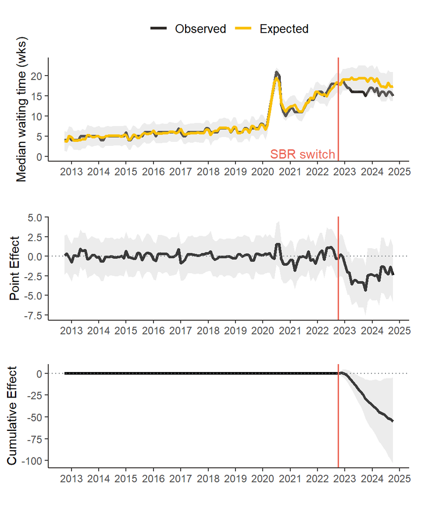

Peterborough

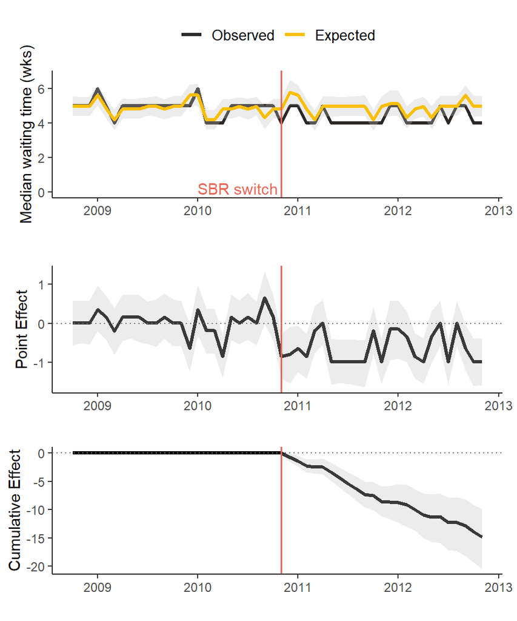

**No change**

Clatterbridge

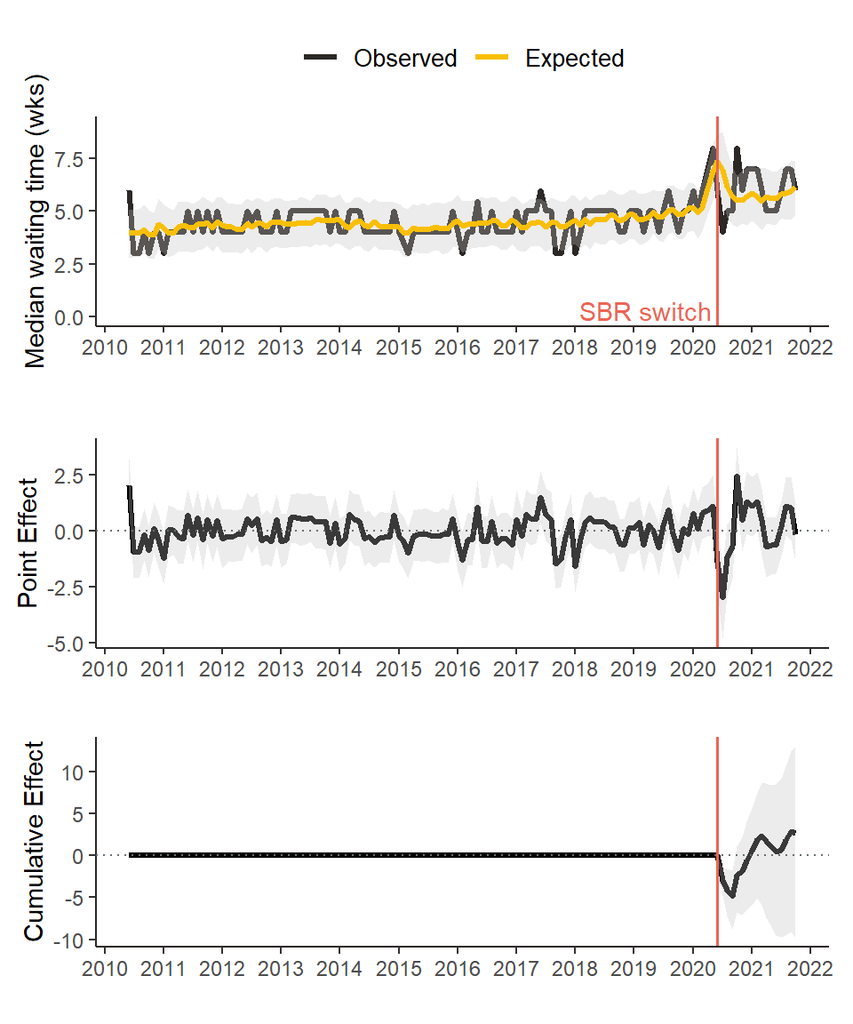

Papworth

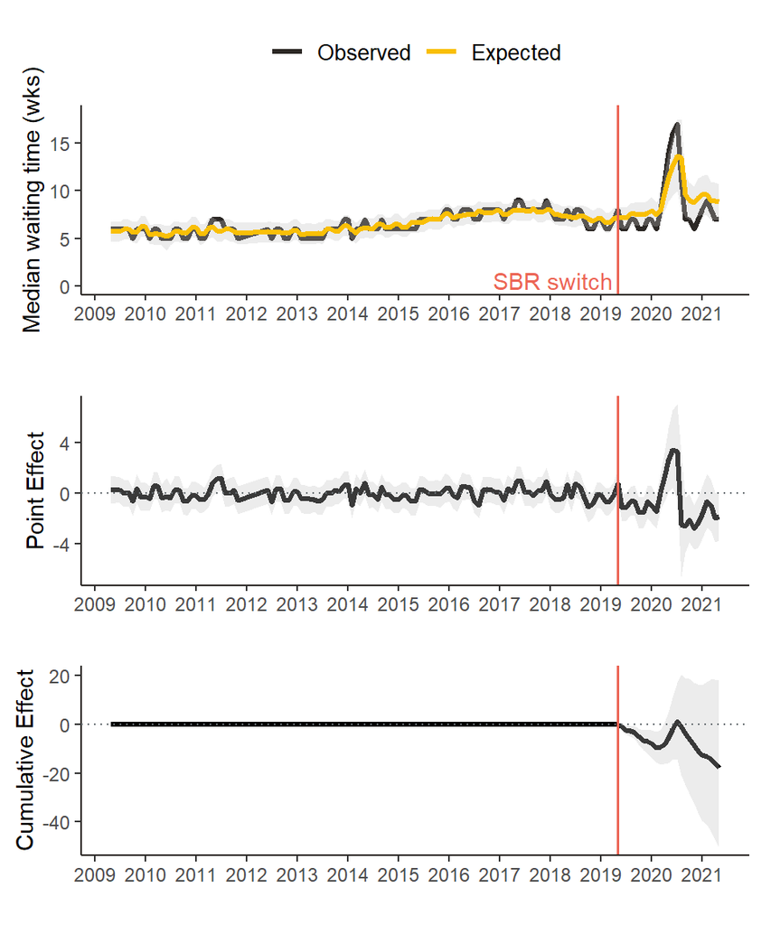

**Increase**

Tunbridge Wells

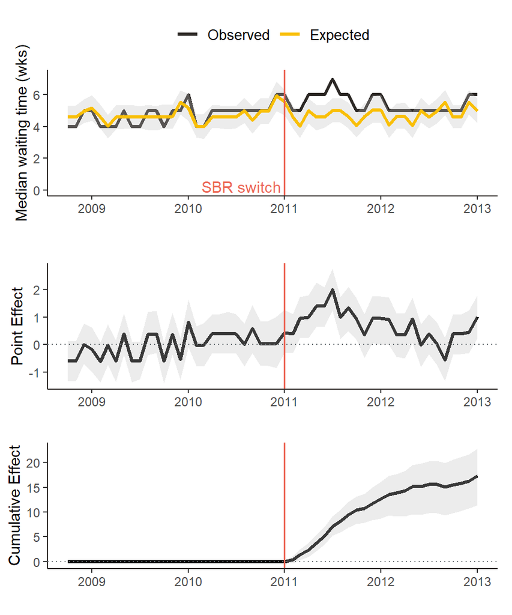

### Bed occupancy

**No change**

Chase Farm

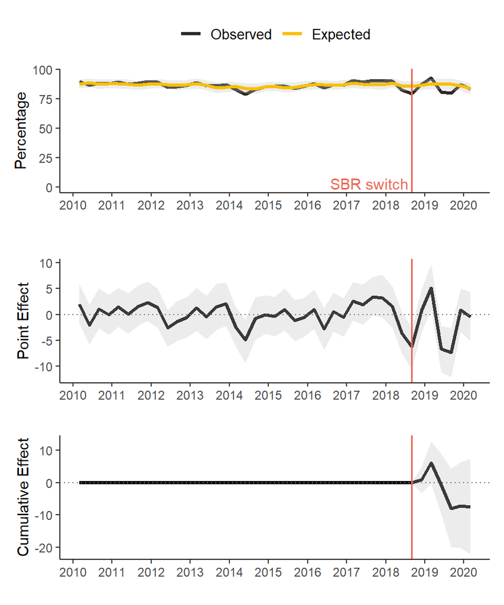

Royal Liverpool

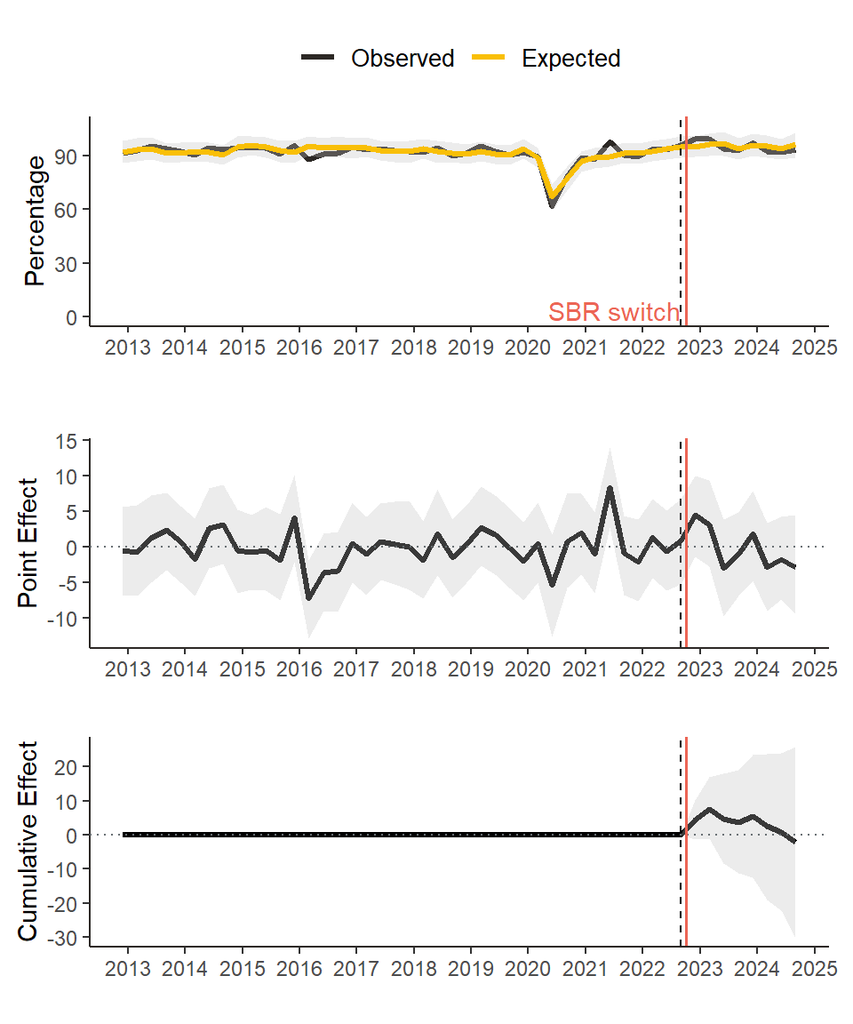

**Increase**

Clatterbridge

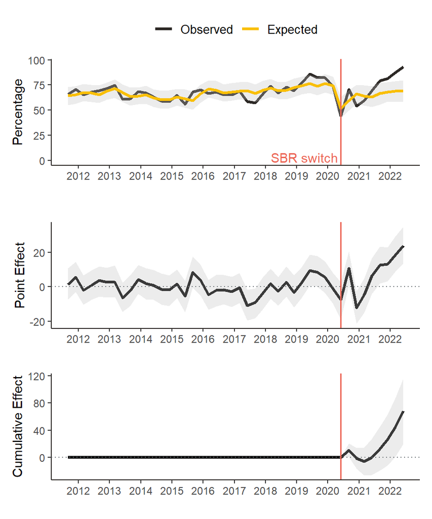

Southmead

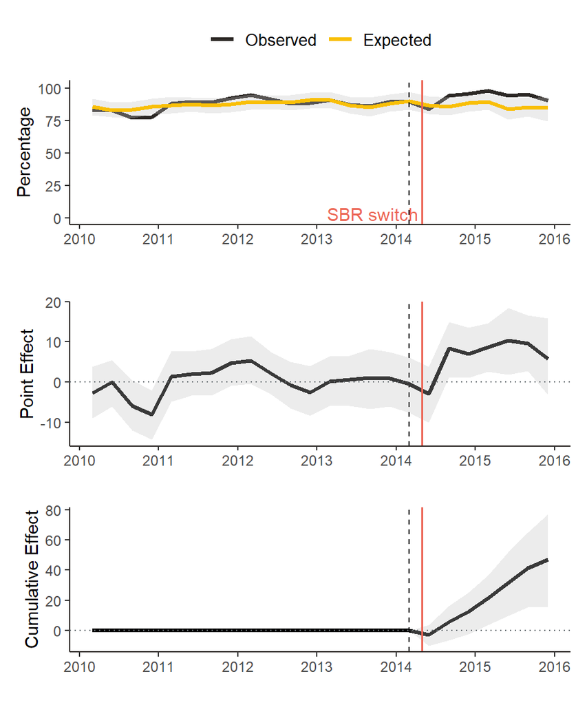

Black dotted line indicates the time of the last data point prior to the switch to single bedrooms

### Emergency readmissions

**Decrease**

Clatterbridge

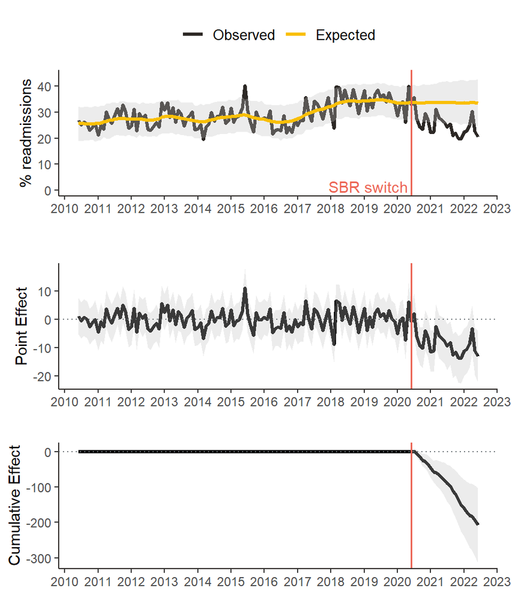

Peterborough

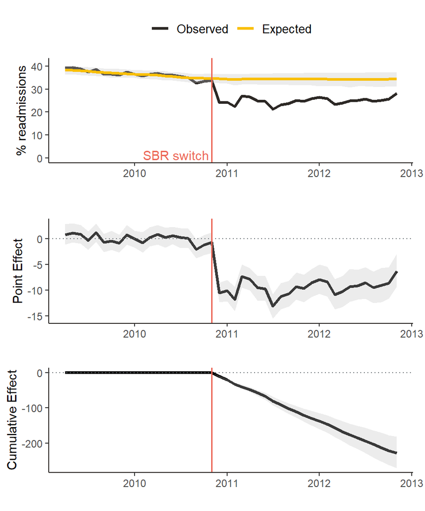

Tunbridge Wells

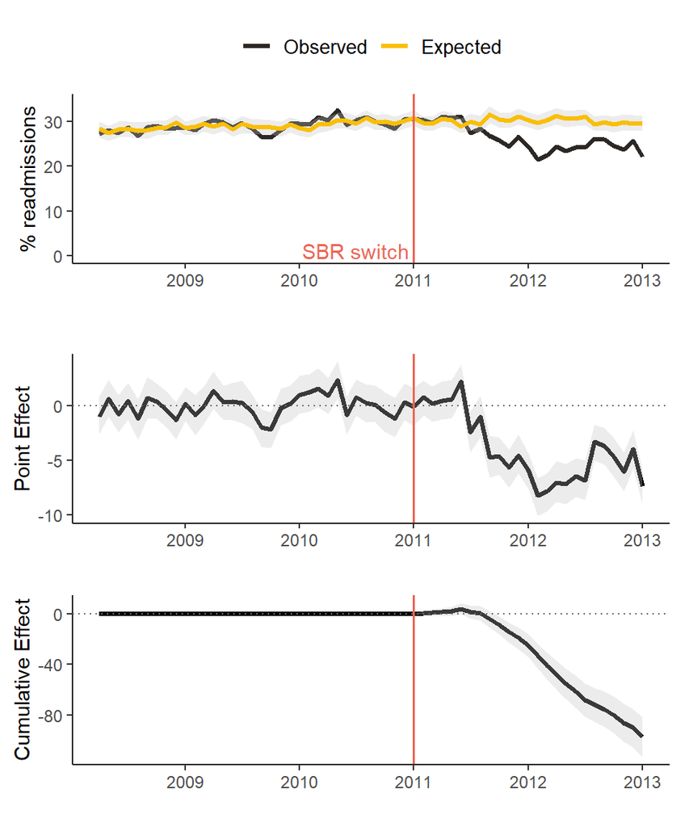

**No change**

Royal Liverpool

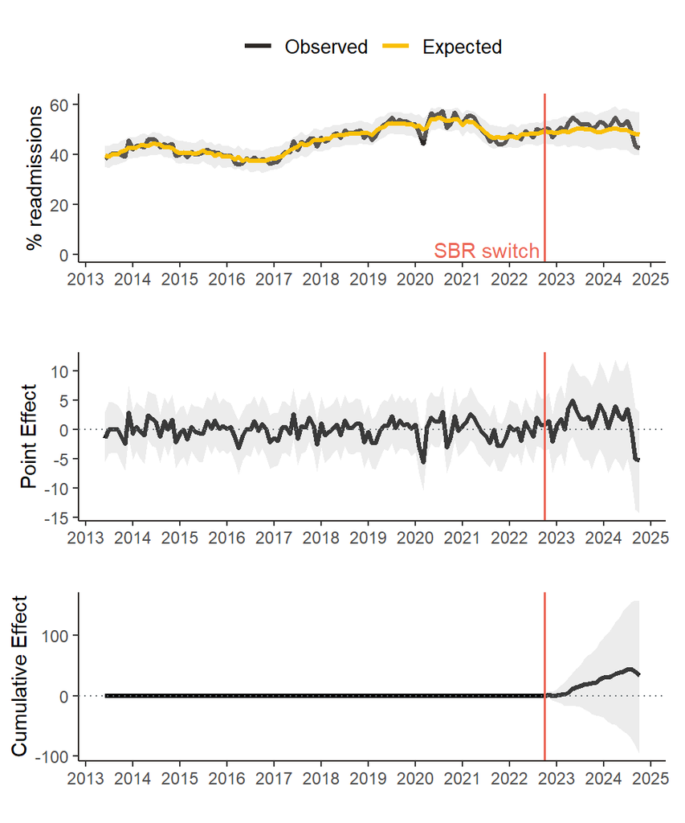

Papworth

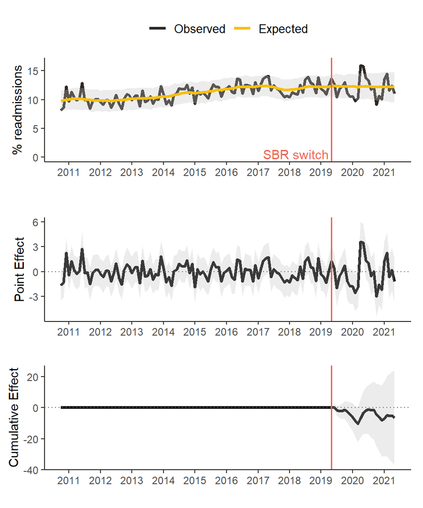

Chase Farm

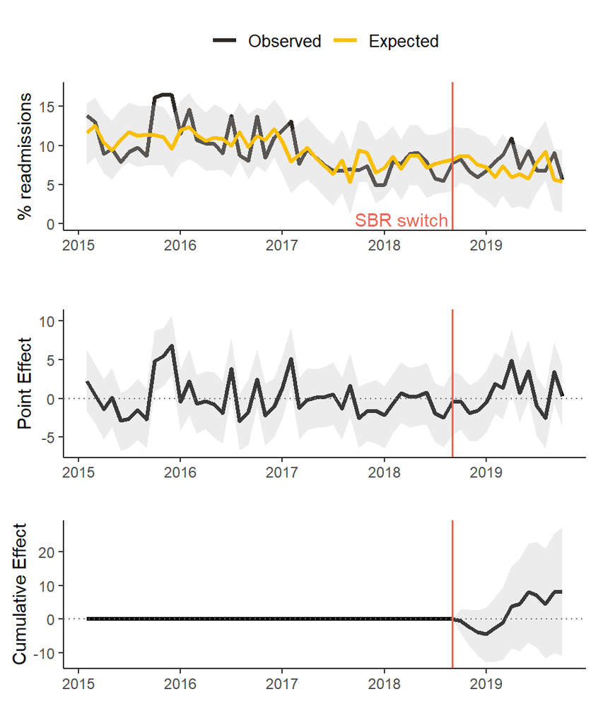

Southmead

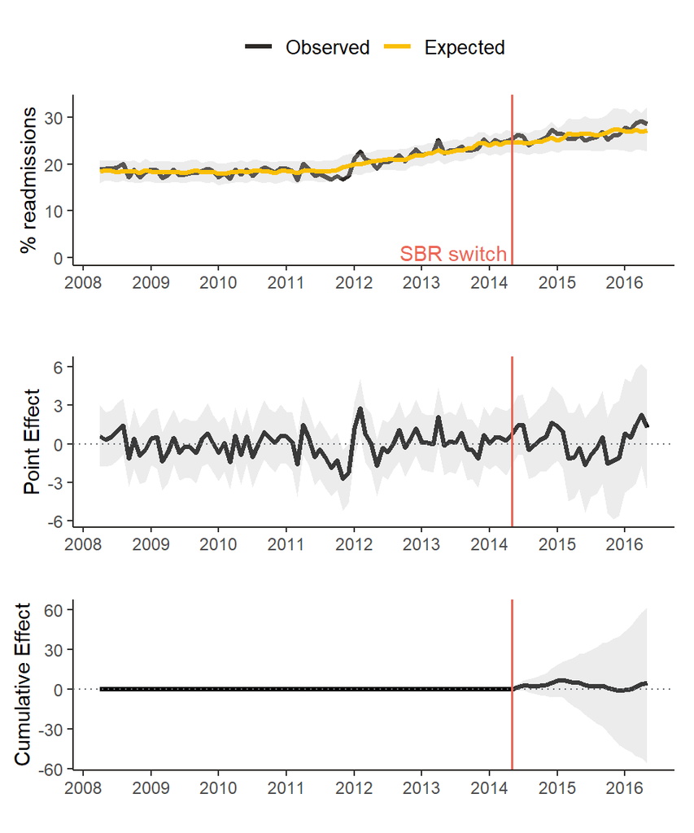

### Cleaning costs

**Decrease**

Papworth (RGM)

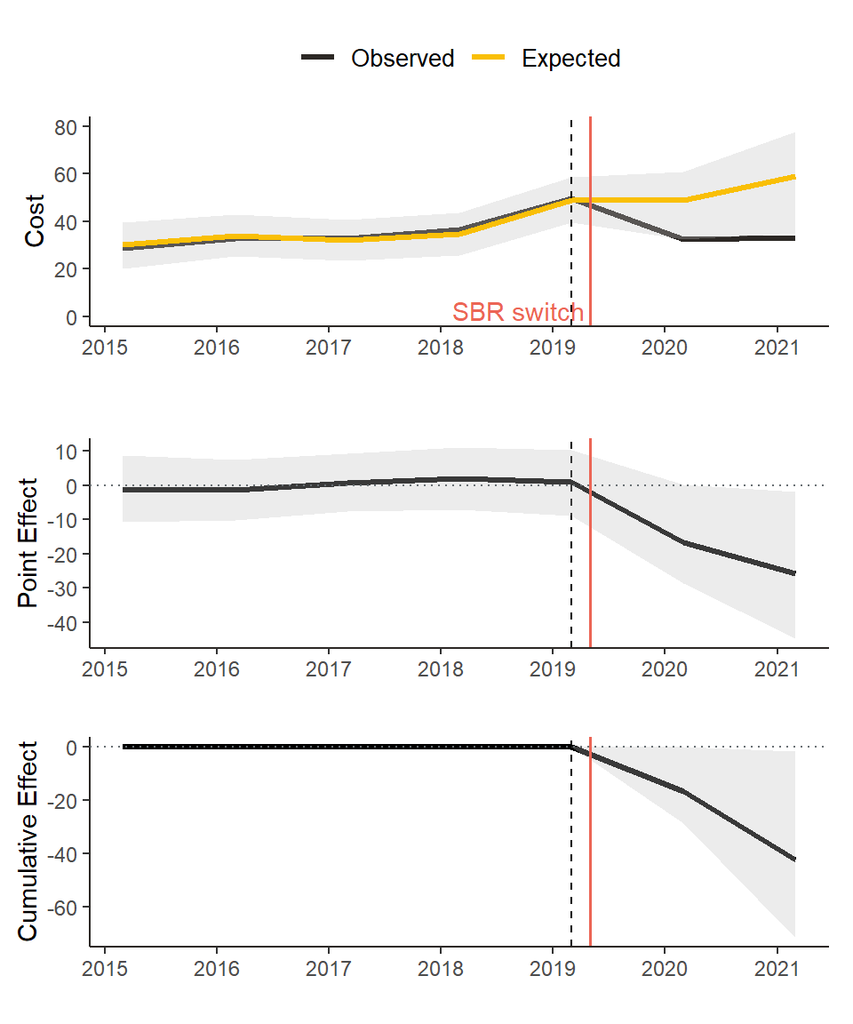

Clatterbridge (REN)

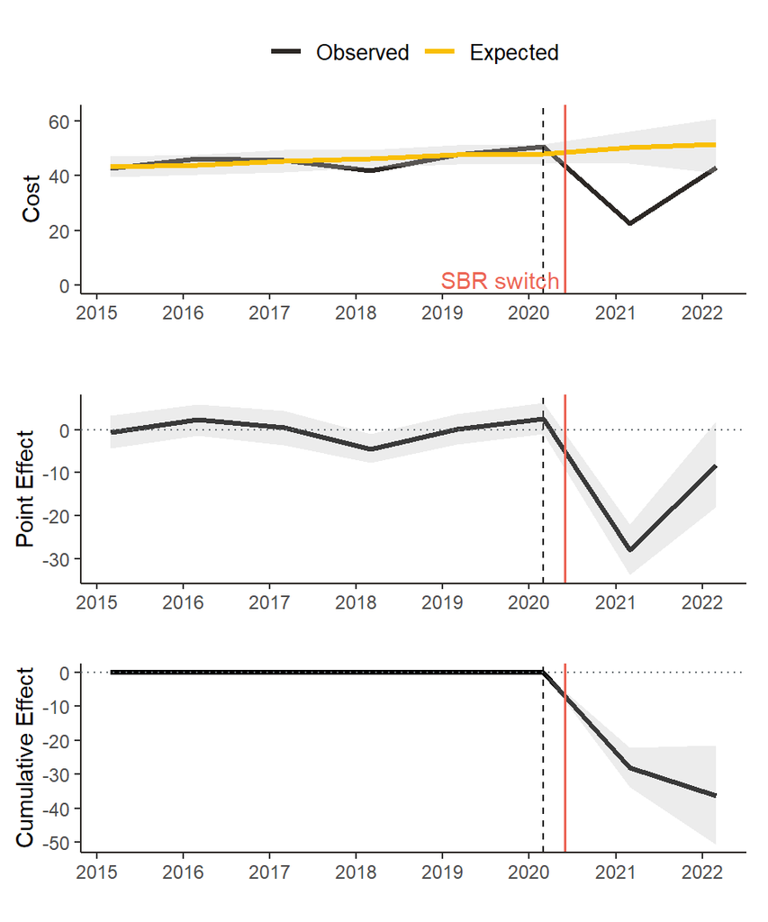

Black dotted line indicates the time of the last data point prior to the switch to single bedrooms

**No change**

Royal Liverpool (REM)

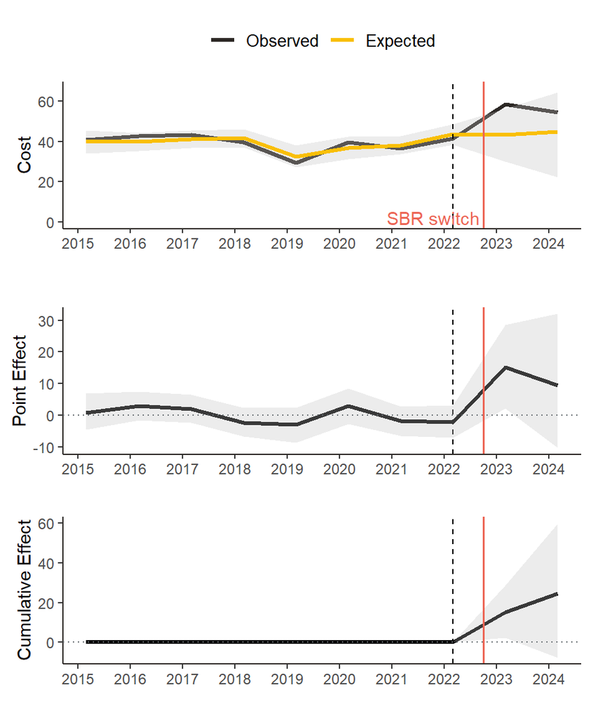

Black dotted line indicates the time of the last data point prior to the switch to single bedrooms

### Deaths in hospital

**Decrease**

Peterborough

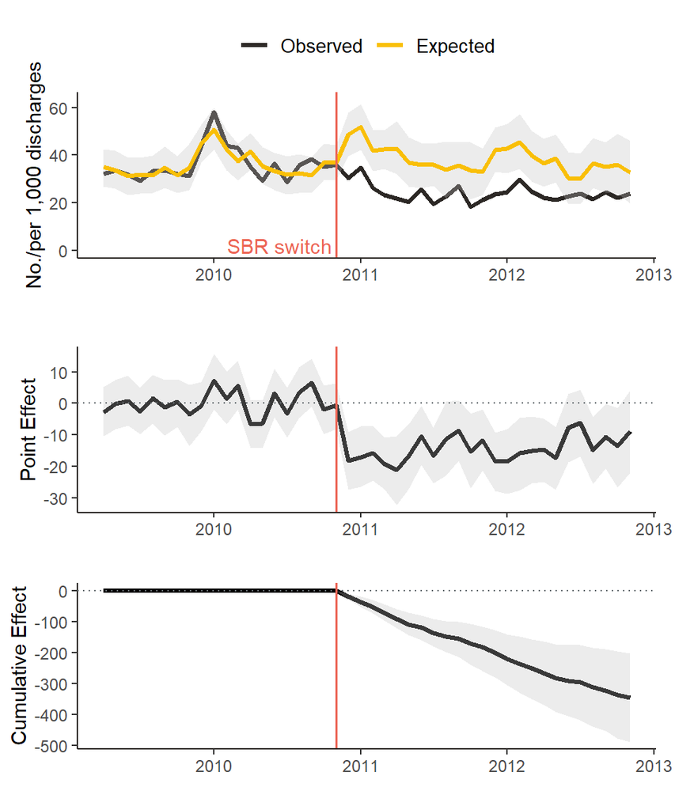

**No change**

Royal Liverpool

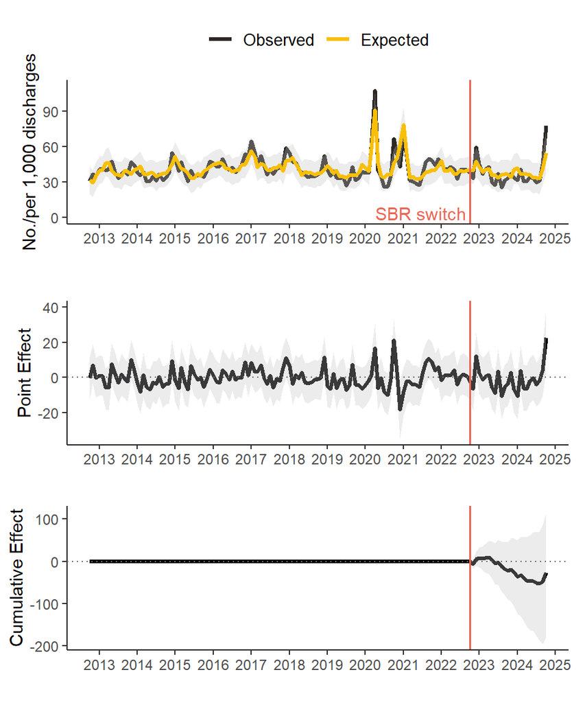

Tunbridge Wells

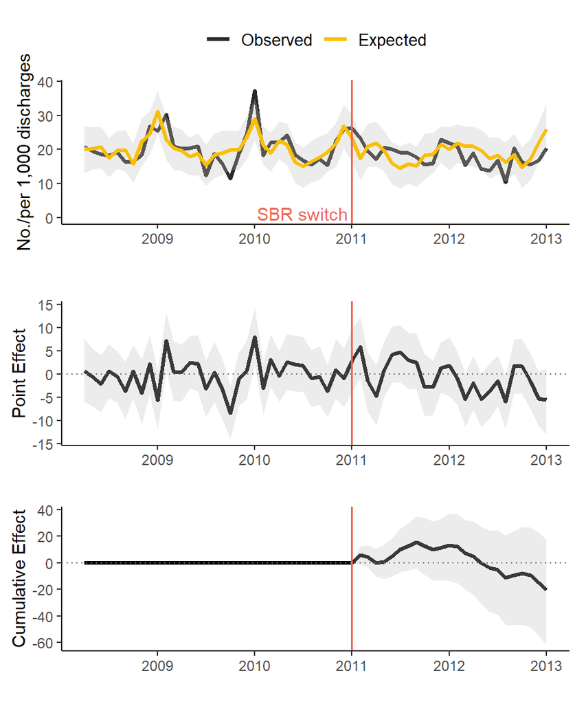

Southmead

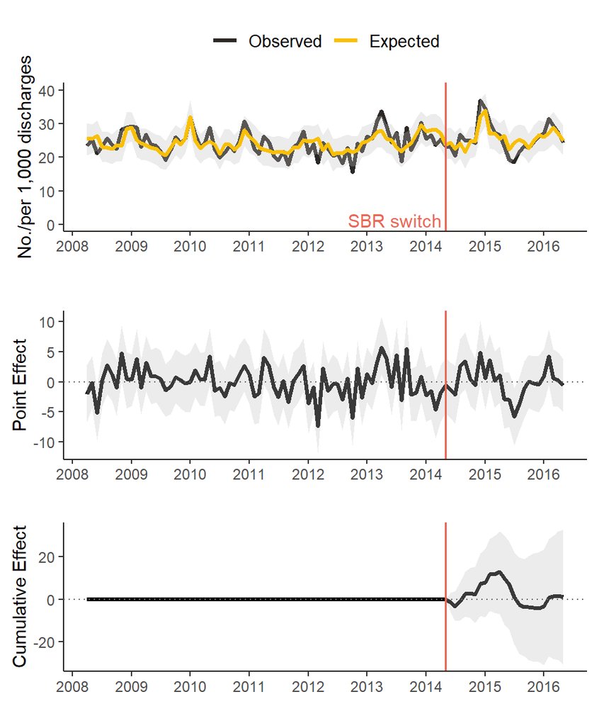

Clatterbridge

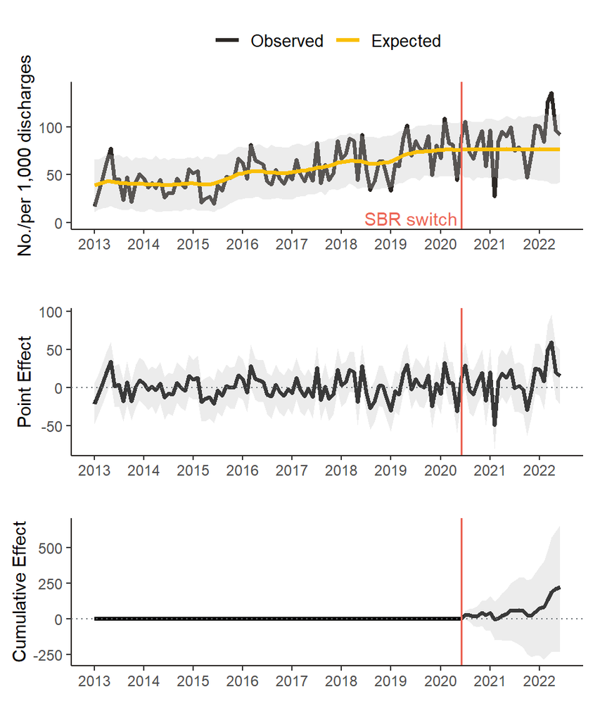

### Falls and injuries in hospital

**Decrease**

Peterborough

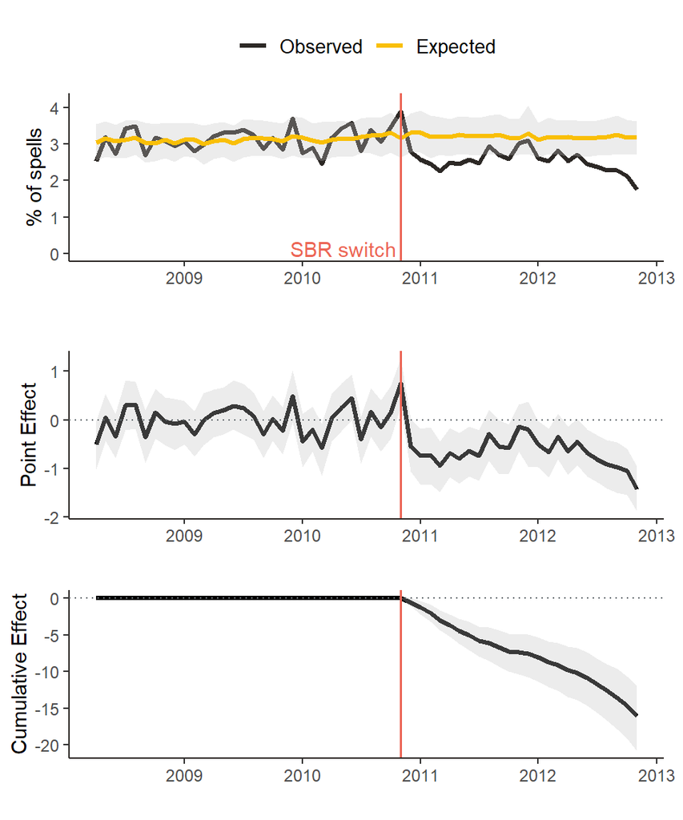

**No change**

Royal Liverpool

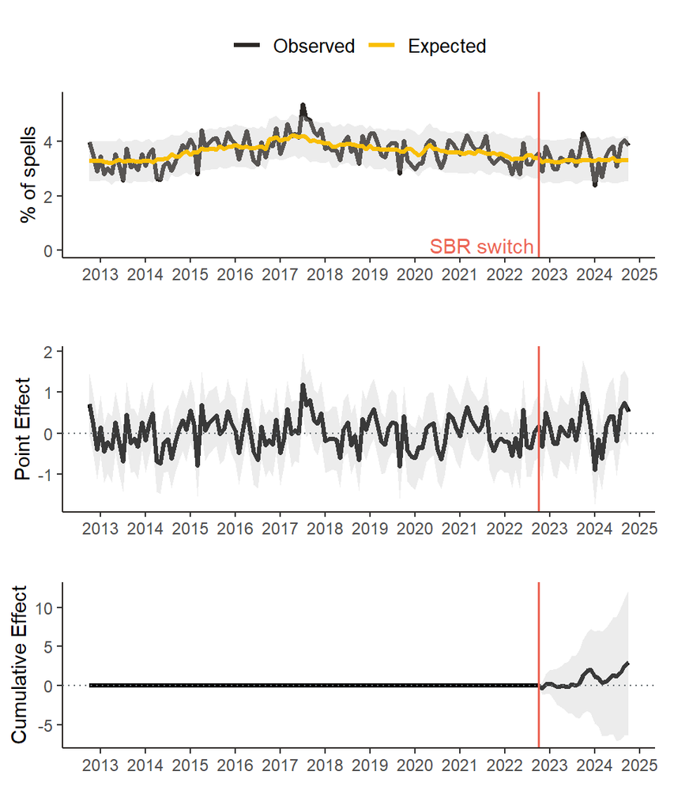

Southmead

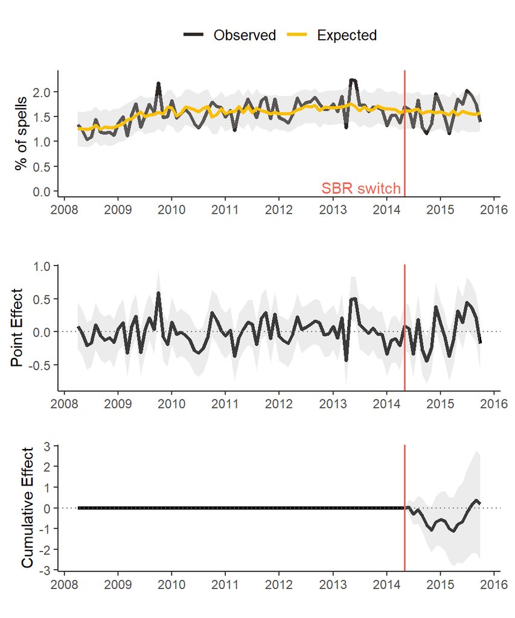

Outcome period is cut short as the rate of falls and fractures at Southmead jumps suddenly in the second year of the outcome period (Nov 2015); this change does not appear to be associated with the change to single rooms as it occurs suddenly almost 18 months after the change to single rooms.

Tunbridge Wells

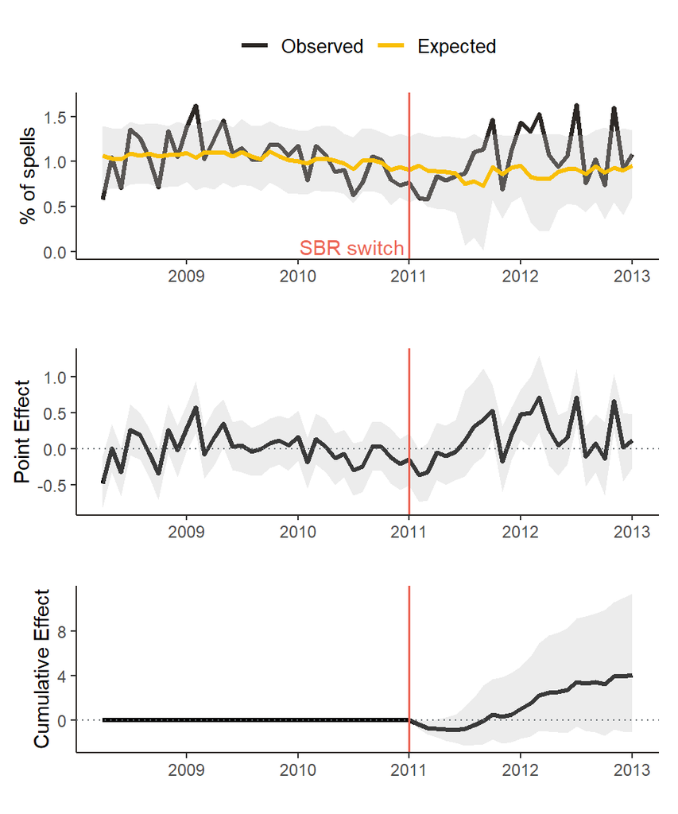

### Healthcare acquired c.difficile infections

**Decrease**

Chase Farm

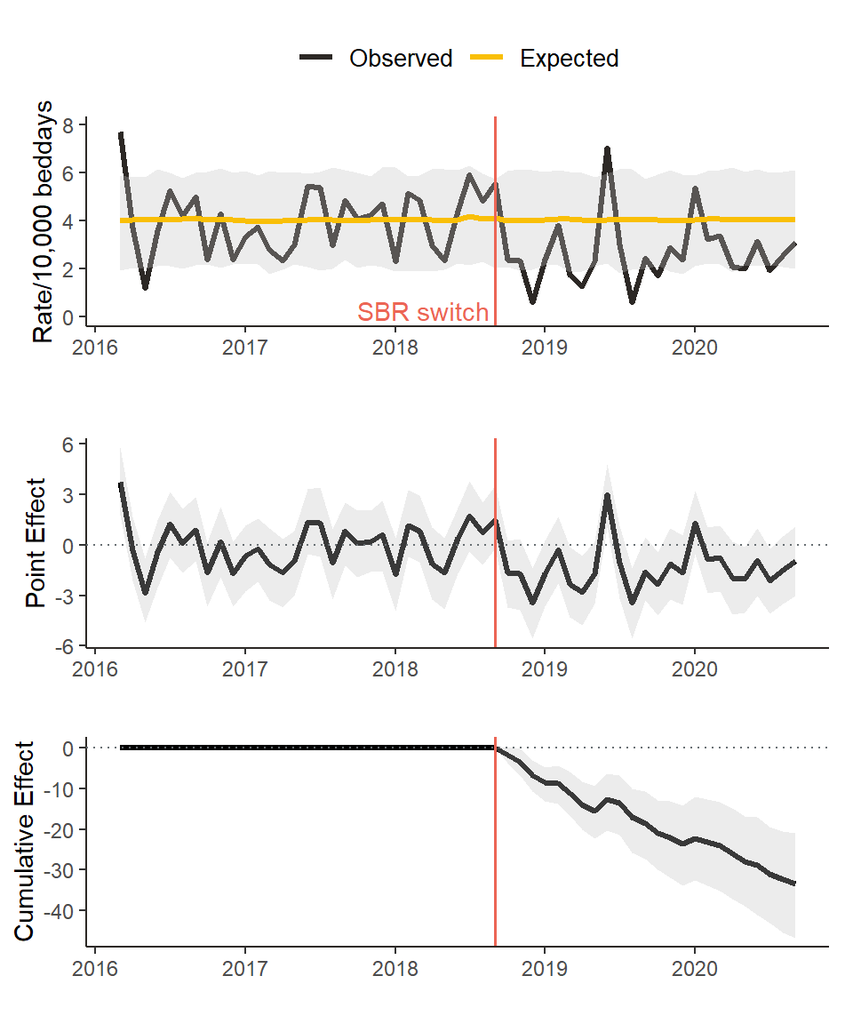

Southmead

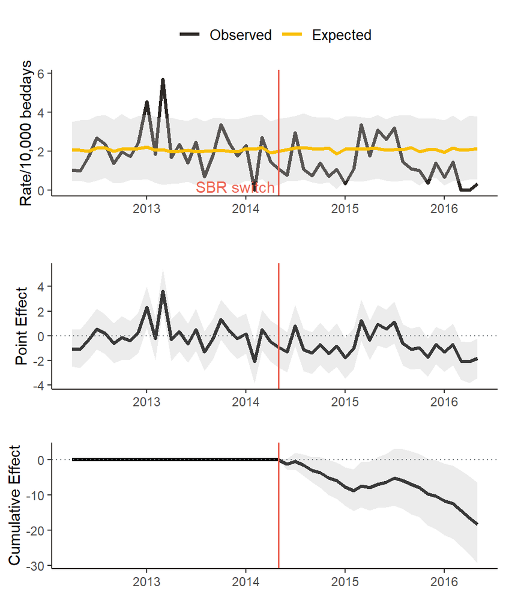

**No change**

Royal Liverpool

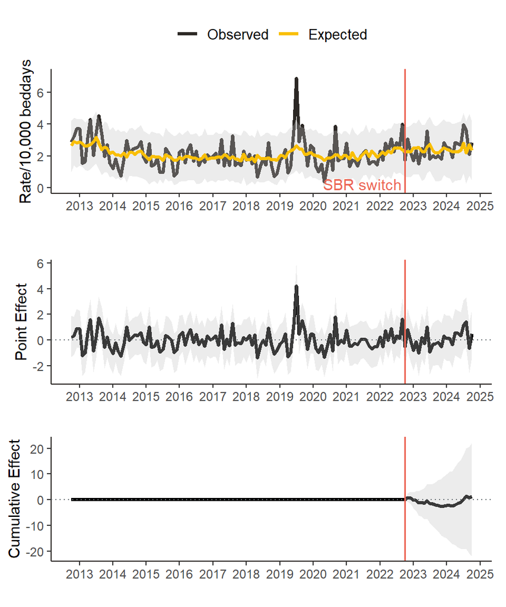

### Patient experience - Friends and Family Test

**Decrease**

Clatterbridge (REN)

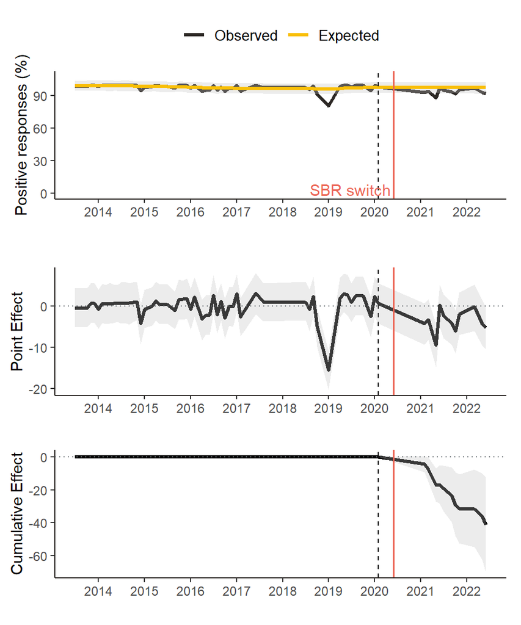

**Increase**

Papworth (RGM)

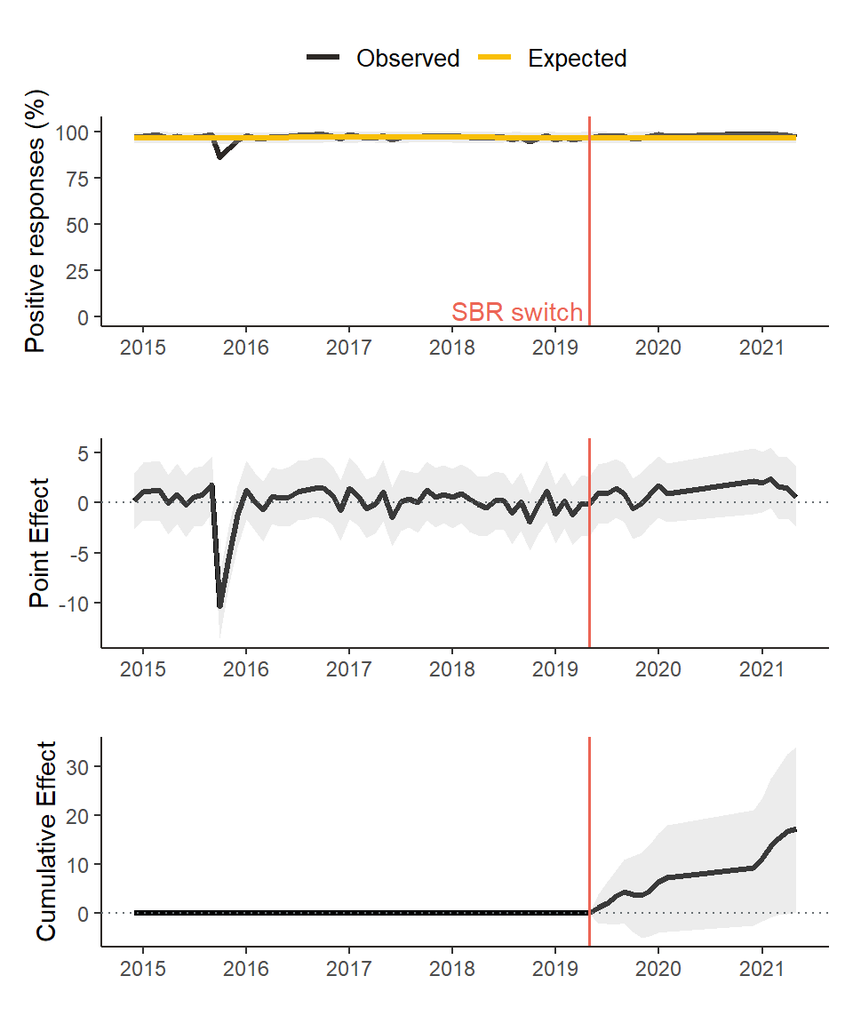

**No Change**

Royal Liverpool (REMRQ)

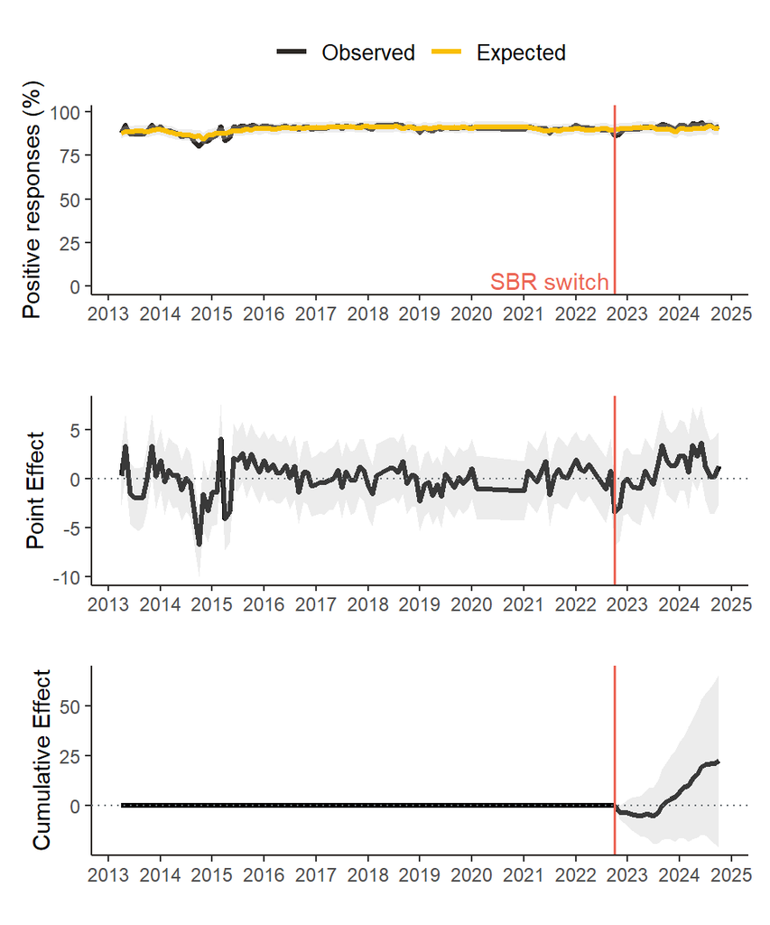

Chase Farm Hospital (RAL)

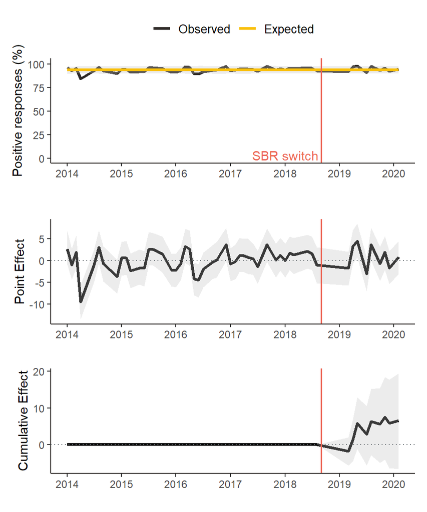

Southmead (RVJ)

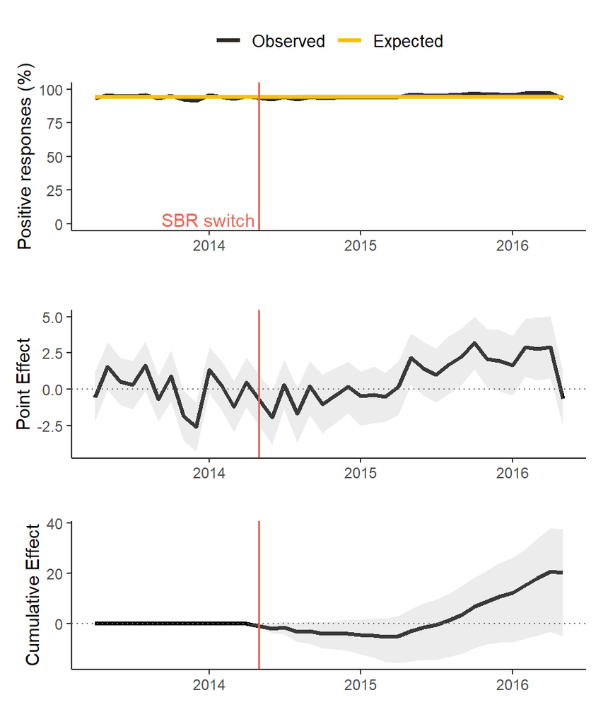

### Staff sickness

**Increase**

Southmead (RVJ)

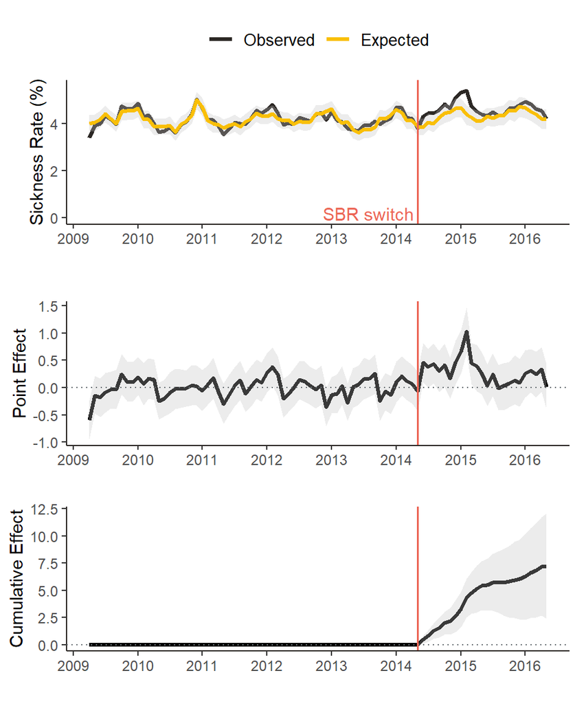

Tunbridge Wells (RWF)

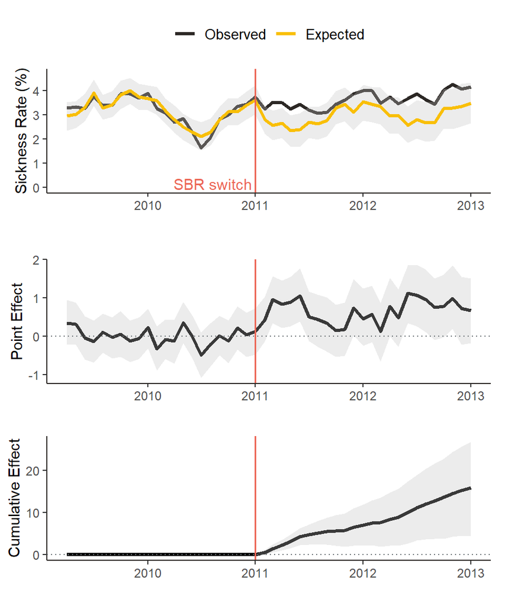

**No change**

Royal Liverpool (REM)

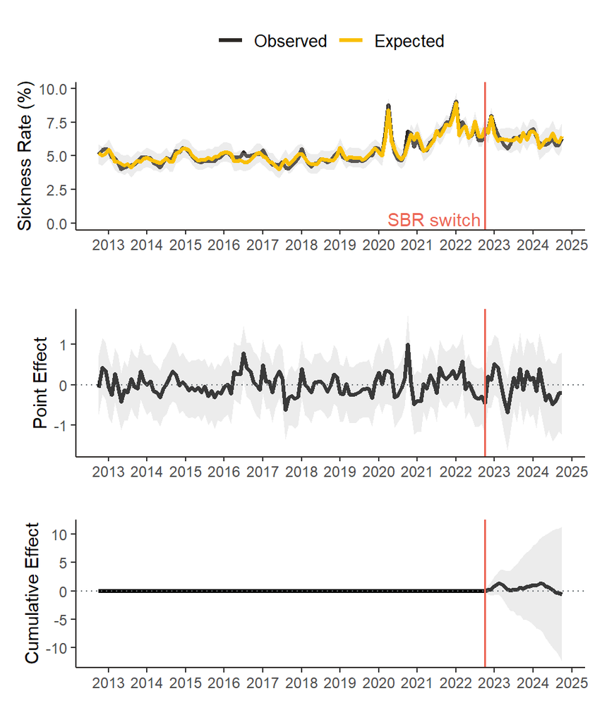

Clatterbridge (REN)

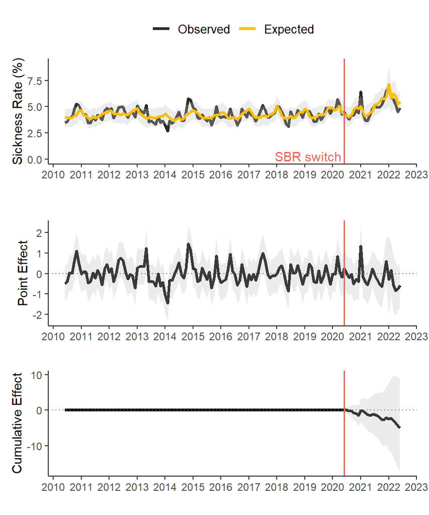

Peterborough (RGN)

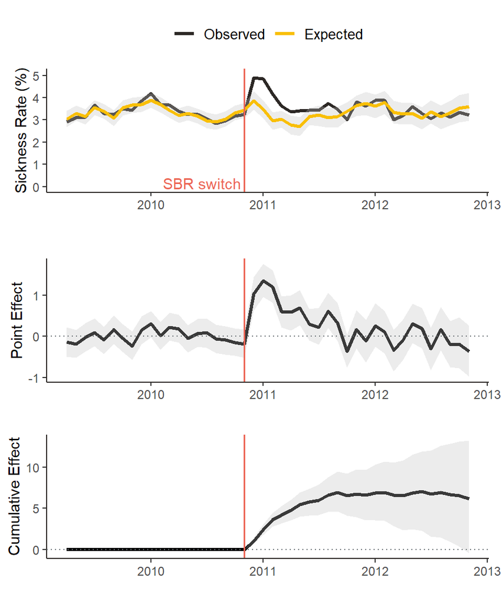

Papworth (RGM)

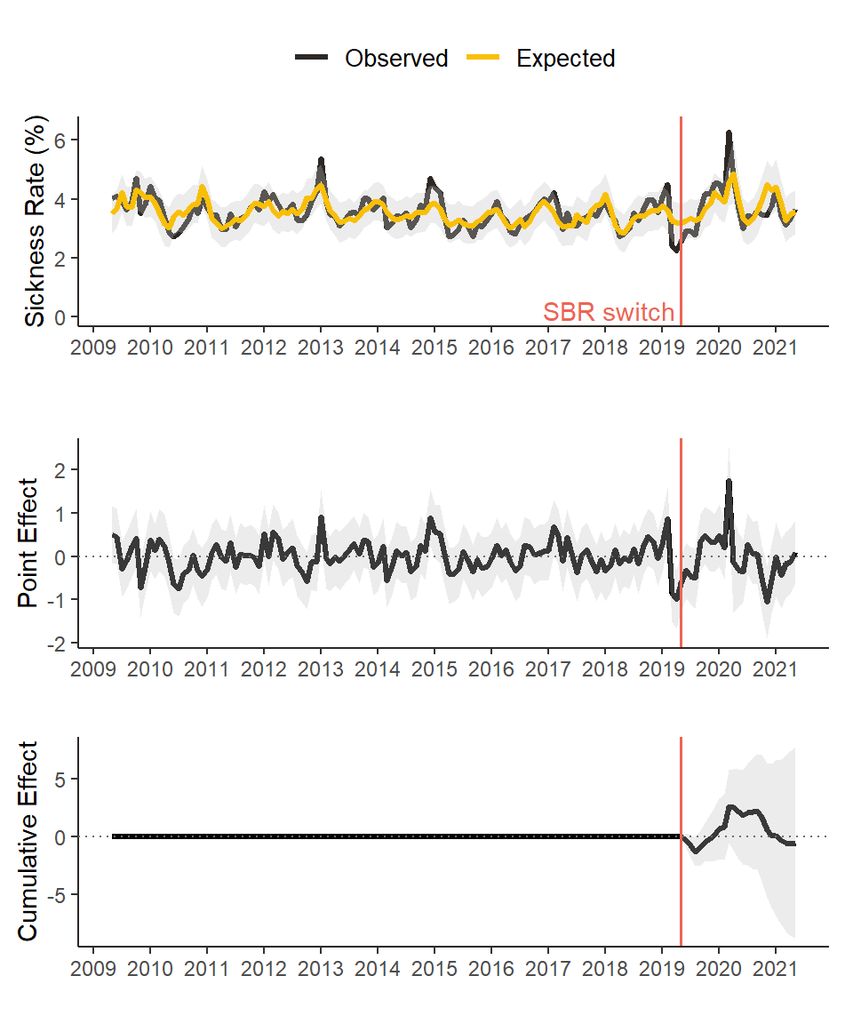

Chase Farm Hospital (RAL)

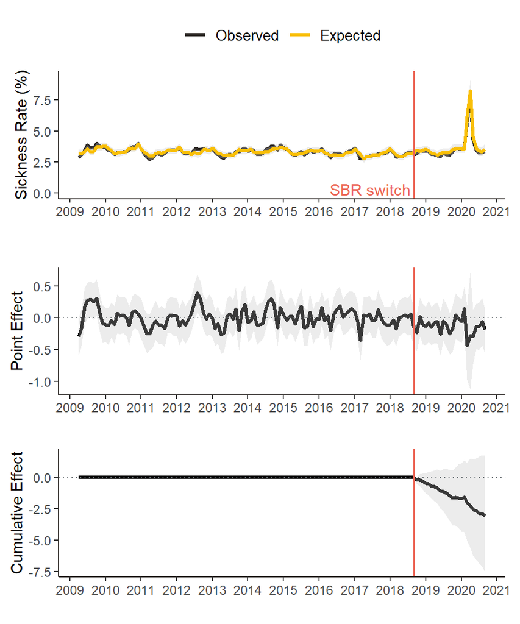

### Staff turnover

#### No change

Royal Liverpool (REM)

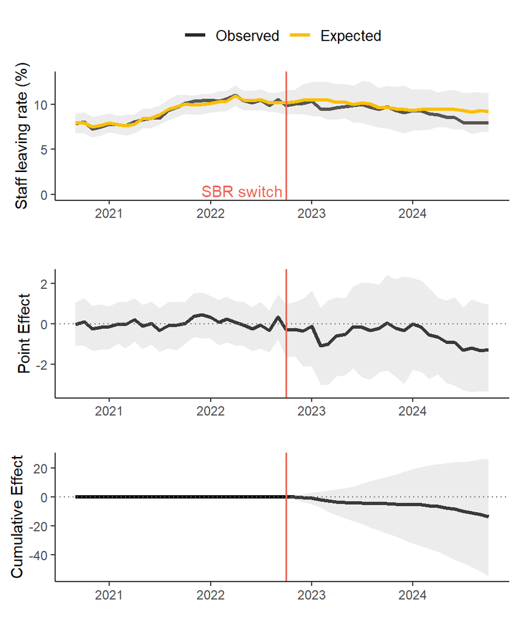

Papworth (RGM)

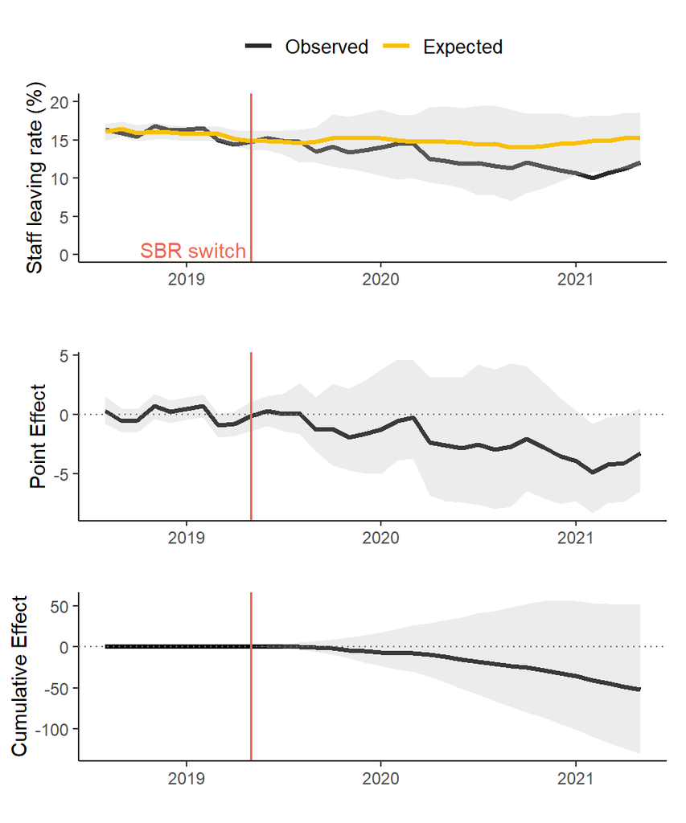

Clatterbridge (REN)

[figure not shown]

### Staff survey

**Decrease**

Clatterbridge (REN)

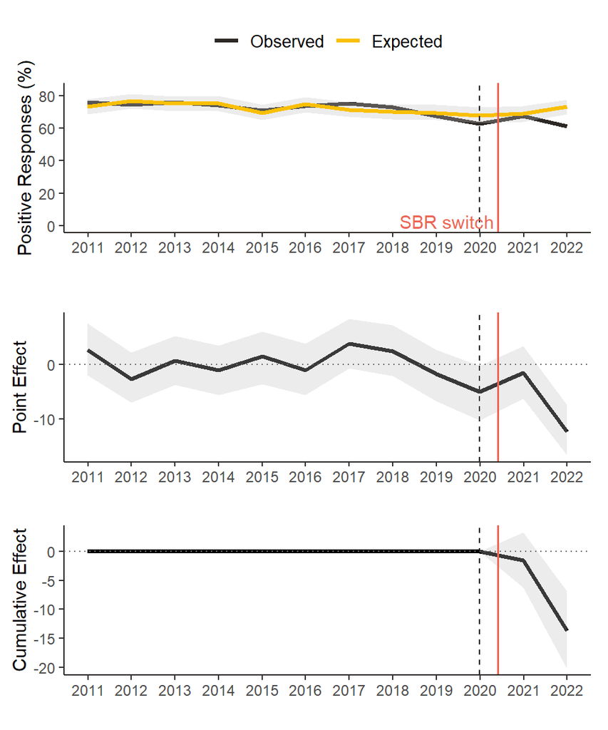

Southmead (RVJ)

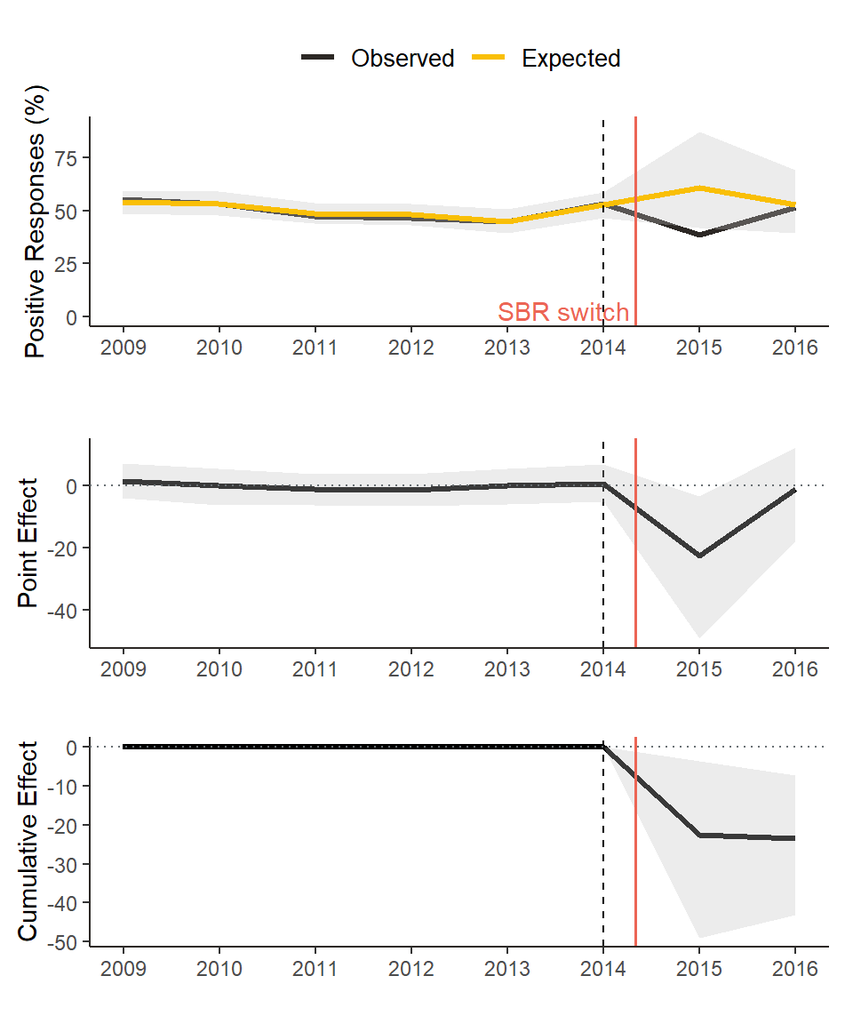

Black dotted line indicates the time of the last data point prior to the switch to single bedrooms

**No change**

Royal Liverpool (REM)

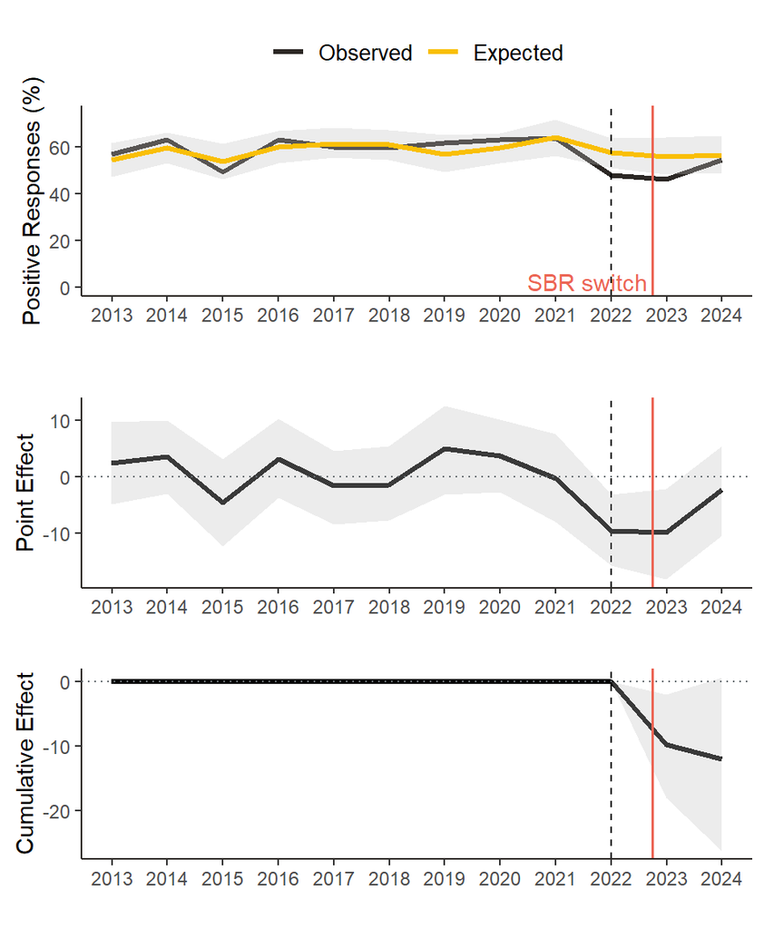

Tunbridge Wells (RWF)

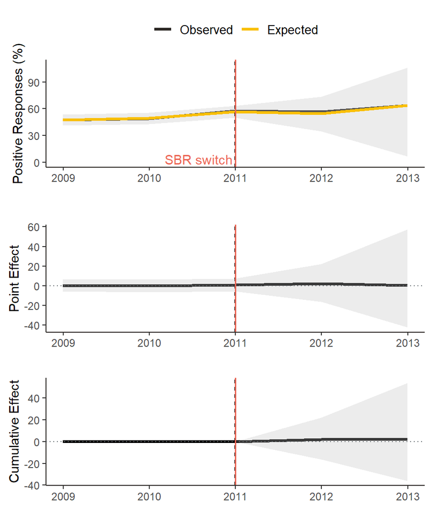

For Tunbridge Wells due to the limited data the controls have been matched using purely correlation rather than dynamic time warping.

Chase Farm (RAL)

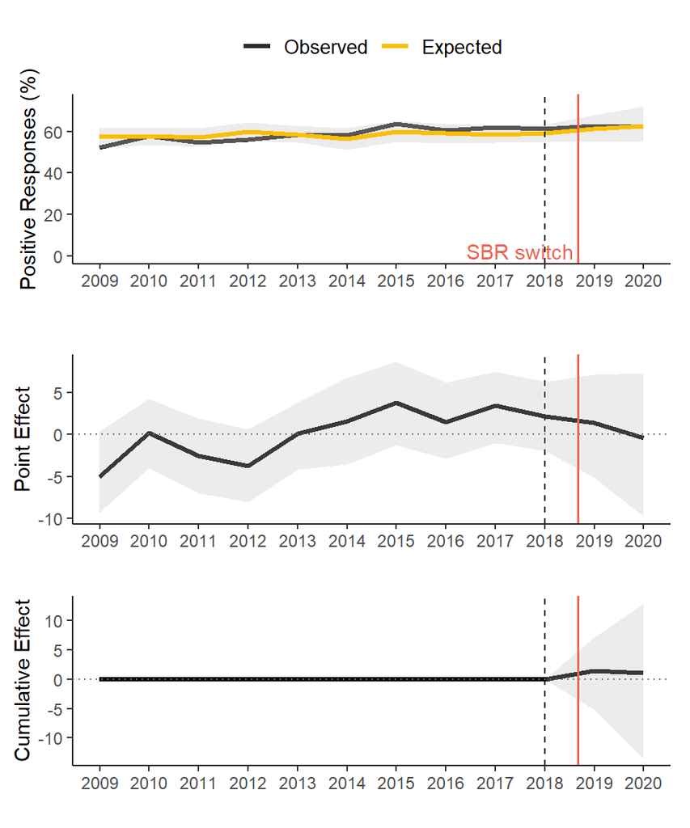

Black dotted line indicates the time of the last data point prior to the switch to single bedrooms

**Increase**

Papworth (RGM)

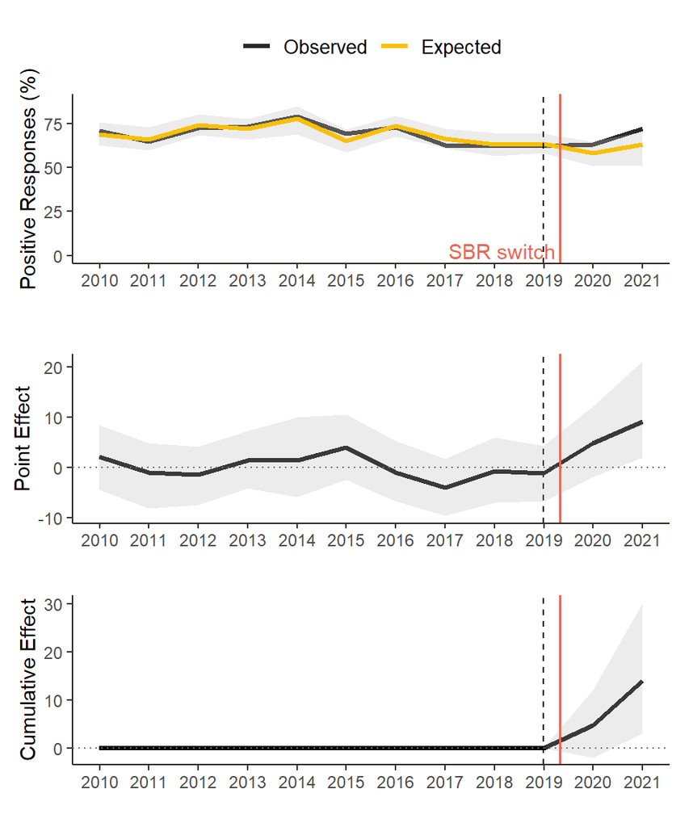

Black dotted line indicates the time of the last data point prior to the switch to single bedrooms

## B. Notes on data quality and suitability (for CIA)

**Referral to treatment waiting time data**

- Only available at provider level.
- This measure is not specific to waiting time for inpatient treatment that will be most impacted by a switch to single bedrooms, as it will include those waiting for diagnostics and for non-admitted treatment.
- Chase Farm was excluded as there was only 4 months of data available in the outcome period.
- Southmead was excluded due to a period of missing data in the 2 years prior to the switch to single rooms.

**Length of stay**

- Papworth was excluded as there were 2 large COVID-19 related spikes in length of stay in the outcome period that were significantly larger than the COVID-19 effects in the control sites, so it was not possible to determine if there would have been a change in length of stay without COVID-19 and thus this data has been excluded from the analysis.

**Bed occupancy**

- Only available at provider level.
- This is a quarterly measure so there is more limited data and depending on the time point at which the switch to single bedrooms occurred there may be no data until 3 months after the switch or the last point of baseline may be 3 months prior to the switch.
- For Papworth bed occupancy was highly affected by COVID-19 in the outcome period, an effect which was not seen to the same extent at the control sites, so it wasn’t possible to determine whether there would have an effect on bed occupancy had COVID-19 not occurred.

**Cleaning costs**

- This is an annual measure, so there are limited data points in the pre-switch period and only 1 or 2 points in the outcome period.
- There was missing occupied floor space data for 2020, 2021 and 2024, so we have imputed values based on the available data and the time point when the switch to single bedrooms occurred.
- This measure is calculated as cost per occupied square metre, but is not specific to inpatient bed areas, but includes all other clinical areas within the hospital, e.g. operating theatres, outpatient clinics etc.
- Meta-analysis is not possible as Royal Liverpool is the only general acute hospital for which we have data.
- For Chase Farm the cleaning costs were quite variable and it was difficult to find appropriate controls, so we were not able to fit a suitable model.

**Healthcare acquired infections**

- Only available at provider level.
- C. difficile infection rates could not be analysed for Clatterbridge or Papworth as the rates were low, often zero, and so combined with the high level of variability in the data it meant it was not possible to fit a suitable model for these sites.
- For other hospital acquired infections the data collections did not go far enough back in time to be used in this analysis.

**Falls and injuries in hospital**

- Clatterbridge, Papworth and Chase Farm were all excluded as the rates were very low, often zero, so it wasn’t possible to fit suitable models to the data.

**Deaths in hospital**

- Papworth was excluded due to a large COVID-19 spike in the outcome period that was greater than that seen in the control sites, so it was not possible to determine if there would have been a change had COVID-19 not occurred.
- Chase Farm was excluded as the rate was very low, often zero, so it wasn’t possible to fit a suitable model, this low rate is unsurprising given it is only conducting elective care.

**Patient experience**

**Staff sickness**

- Only available at provider level.
- This is used as a proxy for staff experience with the assumption that sickness absences would rise if staff were stressed and unhappy in their roles.

**Staff turnover**

- Only available at provider level.
- Meta-analysis is not possible as Royal Liverpool is the only general acute hospital for which we have data.
- This is used as a proxy for staff experience with the assumption that the staff leaving rate may increase if staff are unhappy in their roles.

**Staff survey**

- Only available at provider level.
- This is an annual measure, so there are limited data points in the pre-switch period and only 1 or 2 points in the outcome period.

## C. Control pools for each intervention site

As outlined in Section 8.1, there was a multi-phase control selection process to create a pool of control sites for each intervention site for further analysis. The most similar control sites for each intervention site are shown below. Note that, whilst controls will always be selected from within these sets, the exact controls will not be the same for every indicator as the CIA approach further refines matches based on similar pre-intervention time series.

**Royal Liverpool**

[interactive chart not shown]

| Provider | Provider code | Site | Site code |
| --- | --- | --- | --- |
| Stockport NHS Foundation Trust | RWJ | Stepping Hill Hospital | RWJ09 |
| Royal Devon University Healthcare NHS Foundation Trust | RH8 | Royal Devon & Exeter Hospital (Wonford) | RH801 |
| Royal Berkshire NHS Foundation Trust | RHW | Royal Berkshire Hospital | RHW01 |
| Medway NHS Foundation Trust | RPA | Medway Maritime Hospital | RPA02 |
| Dartford and Gravesham NHS Trust | RN7 | Darent Valley Hospital | RN707 |
| East Sussex Healthcare NHS Trust | RXC | Conquest Hospital | RXC01 |
| Royal Cornwall Hospitals NHS Trust | REF | Royal Cornwall Hospital (Treliske) | REF12 |
| Worcestershire Acute Hospitals NHS Trust | RWP | Worcestershire Royal Hospital | RWP50 |
| Bedfordshire Hospitals NHS Foundation Trust | RC9 | Bedford Hospital South Wing | RC979 |
| Sandwell and West Birmingham Hospitals NHS Trust | RXK | Sandwell General Hospital | RXK01 |
| Sandwell and West Birmingham Hospitals NHS Trust | RXK | City Hospital | RXK02 |
| Lancashire Teaching Hospitals NHS Foundation Trust | RXN | Royal Preston Hospital | RXN02 |
| Northampton General Hospital NHS Trust | RNS | Northampton General Hospital (Acute) | RNS01 |
| Barking, Havering and Redbridge University Hospitals NHS Trust | RF4 | Queen's Hospital | RF4QH |
| Hampshire Hospitals NHS Foundation Trust | RN5 | Basingstoke and North Hampshire Hospital | RN506 |
| Kettering General Hospital NHS Foundation Trust | RNQ | Kettering General Hospital | RNQ51 |
| Surrey and Sussex Healthcare NHS Trust | RTP | East Surrey Hospital | RTP04 |
| Royal Surrey County Hospital NHS Foundation Trust | RA2 | Royal Surrey County Hospital | RA201 |
| West Suffolk NHS Foundation Trust | RGR | West Suffolk Hospital | RGR50 |
| East Kent Hospitals University NHS Foundation Trust | RVV | William Harvey Hospital (Ashford) | RVV01 |

n: 20

**Clatterbridge**

[interactive chart not shown]

| Provider | Provider code | Site | Site code |
| --- | --- | --- | --- |
| The Newcastle Upon Tyne Hospitals NHS Foundation Trust | RTD | Northern Centre For Cancer Care | RTD06 |
| University Hospitals Bristol and Weston NHS Foundation Trust | RA7 | Bristol Haematology & Oncology Centre | RA710 |
| The Christie NHS Foundation Trust | RBV | The Christie | RBV01 |
| Sheffield Teaching Hospitals NHS Foundation Trust | RHQ | Weston Park Hospital | RHQWP |

n: 4

**Royal Papworth**

[interactive chart not shown]

| Provider | Provider code | Site | Site code |
| --- | --- | --- | --- |
| Imperial College Healthcare NHS Trust | RYJ | Hammersmith Hospital | RYJ03 |
| Blackpool Teaching Hospitals NHS Foundation Trust | RXL | Blackpool Victoria Hospital | RXL01 |
| Leeds Teaching Hospitals NHS Trust | RR8 | Leeds General Infirmary | RR801 |
| Leeds Teaching Hospitals NHS Trust | RR8 | St James's University Hospital | RR813 |
| University Hospitals Of North Midlands NHS Trust | RJE | Royal Stoke University Hospital | RJE01 |
| South Tees Hospitals NHS Foundation Trust | RTR | The James Cook University Hospital | RTRAT |
| Nottingham University Hospitals NHS Trust | RX1 | Nottingham University Hospitals NHS Trust - City Campus | RX1CC |
| University Hospitals Bristol and Weston NHS Foundation Trust | RA7 | Bristol Royal Infirmary | RA701 |
| Sheffield Teaching Hospitals NHS Foundation Trust | RHQ | Northern General Hospital | RHQNG |

n: 9

**Peterborough**

[interactive chart not shown]

| Provider | Provider code | Site | Site code |
| --- | --- | --- | --- |
| East Suffolk and North Essex NHS Foundation Trust | RDE | Colchester General Hospital | RDEE4 |
| Northampton General Hospital NHS Trust | RNS | Northampton General Hospital (Acute) | RNS01 |
| St George's University Hospitals NHS Foundation Trust | RJ7 | St George's Hospital (Tooting) | RJ701 |
| Ashford and St Peter's Hospitals NHS Foundation Trust | RTK | St Peter's Hospital | RTK01 |
| Royal United Hospitals Bath NHS Foundation Trust | RD1 | Royal United Hospital | RD130 |
| Royal Liverpool and Broadgreen University Hospitals NHS Trust | RQ6 | The Royal Liverpool University Hospital | RQ617 |
| West Hertfordshire Teaching Hospitals NHS Trust | RWG | Watford General Hospital | RWG02 |
| Worcestershire Acute Hospitals NHS Trust | RWP | Worcestershire Royal Hospital | RWP50 |
| Mid Staffordshire NHS Foundation Trust | RJD | Stafford Hospital | RJD01 |
| Bolton NHS Foundation Trust | RMC | Royal Bolton Hospital | RMC01 |
| Sandwell and West Birmingham Hospitals NHS Trust | RXK | Sandwell General Hospital | RXK01 |
| Royal Cornwall Hospitals NHS Trust | REF | Royal Cornwall Hospital (Treliske) | REF12 |
| Epsom and St Helier University Hospitals NHS Trust | RVR | St Helier Hospital | RVR05 |
| Taunton and Somerset NHS Foundation Trust | RBA | Musgrove Park Hospital | RBA11 |
| Brighton and Sussex University Hospitals NHS Trust | RXH | Royal Sussex County Hospital | RXH01 |
| Lancashire Teaching Hospitals NHS Foundation Trust | RXN | Chorley & South Ribble Hospital | RXN01 |
| Lancashire Teaching Hospitals NHS Foundation Trust | RXN | Royal Preston Hospital | RXN02 |
| Medway NHS Foundation Trust | RPA | Medway Maritime Hospital | RPA02 |
| Kettering General Hospital NHS Foundation Trust | RNQ | Kettering General Hospital | RNQ51 |
| Countess Of Chester Hospital NHS Foundation Trust | RJR | Countess Of Chester Hospital | RJR05 |

n: 20

**Chase Farm**

[interactive chart not shown]

| Provider | Provider code | Site | Site code |
| --- | --- | --- | --- |
| Manchester University NHS Foundation Trust | R0A | Trafford General Hospital | R0A09 |
| Imperial College Healthcare NHS Trust | RYJ | Queen Charlotte's Hospital | RYJ04 |
| University Hospitals Of North Midlands NHS Trust | RJE | County Hospital | RJE09 |
| King's College Hospital NHS Foundation Trust | RJZ | Princess Royal University Hospital | RJZ30 |
| King's College Hospital NHS Foundation Trust | RJZ | Orpington Hospital | RJZ70 |
| South Tees Hospitals NHS Foundation Trust | RTR | Friarage Hospital Site | RTR45 |
| Doncaster and Bassetlaw Teaching Hospitals NHS Foundation Trust | RP5 | Montagu Hospital | RP5MM |
| Doncaster and Bassetlaw Teaching Hospitals NHS Foundation Trust | RP5 | Bassetlaw Hospital | RP5BA |
| University Hospitals Of Derby and Burton NHS Foundation Trust | RTG | Florence Nightingale Community Hospital | RTGFA |
| East Lancashire Hospitals NHS Trust | RXR | Burnley General Hospital | RXR10 |
| Harrogate and District NHS Foundation Trust | RCD | Harrogate District Hospital | RCD01 |
| Pennine Acute Hospitals NHS Trust | RW6 | Rochdale Infirmary | RW604 |
| Pennine Acute Hospitals NHS Trust | RW6 | Fairfield General Hospital | RW601 |
| The Robert Jones and Agnes Hunt Orthopaedic Hospital NHS Foundation Trust | RL1 | Robert Jones & Agnes Hunt Orthopaedic Hospital | RL131 |
| Bradford Teaching Hospitals NHS Foundation Trust | RAE | St Lukes Hospital | RAE05 |
| Calderdale and Huddersfield NHS Foundation Trust | RWY | Huddersfield Royal Infirmary | RWY01 |
| Hampshire Hospitals NHS Foundation Trust | RN5 | Basingstoke and North Hampshire Hospital | RN506 |
| Hampshire Hospitals NHS Foundation Trust | RN5 | Royal Hampshire County Hospital | RN541 |
| North Cumbria University Hospitals NHS Trust | RNL | Cumberland Infirmary | RNLAY |
| North Cumbria University Hospitals NHS Trust | RNL | West Cumberland Hospital | RNLBX |

n: 20

**Southmead**

[interactive chart not shown]

| Provider | Provider code | Site | Site code |
| --- | --- | --- | --- |
| Lancashire Teaching Hospitals NHS Foundation Trust | RXN | Chorley & South Ribble Hospital | RXN01 |
| Lancashire Teaching Hospitals NHS Foundation Trust | RXN | Royal Preston Hospital | RXN02 |
| Ashford and St Peter's Hospitals NHS Foundation Trust | RTK | St Peter's Hospital | RTK01 |
| Mid and South Essex NHS Foundation Trust | RAJ | Southend Hospital | RAJ01 |
| Royal Liverpool and Broadgreen University Hospitals NHS Trust | RQ6 | The Royal Liverpool University Hospital | RQ617 |
| Royal Surrey County Hospital NHS Foundation Trust | RA2 | Royal Surrey County Hospital | RA201 |
| Hampshire Hospitals NHS Foundation Trust | RN5 | Basingstoke and North Hampshire Hospital | RN506 |
| East and North Hertfordshire NHS Trust | RWH | Lister Hospital | RWH01 |
| University Hospitals Plymouth NHS Trust | RK9 | Derriford Hospital | RK950 |
| East Kent Hospitals University NHS Foundation Trust | RVV | Queen Elizabeth The Queen Mother Hospital | RVV09 |
| East Kent Hospitals University NHS Foundation Trust | RVV | William Harvey Hospital (Ashford) | RVV01 |
| Worcestershire Acute Hospitals NHS Trust | RWP | Alexandra Hospital | RWP01 |
| Worcestershire Acute Hospitals NHS Trust | RWP | Worcestershire Royal Hospital | RWP50 |
| Burton Hospitals NHS Foundation Trust | RJF | Queen's Hospital, Burton Upon Trent | RJF02 |
| Royal United Hospitals Bath NHS Foundation Trust | RD1 | Royal United Hospital | RD130 |
| Royal Cornwall Hospitals NHS Trust | REF | Royal Cornwall Hospital (Treliske) | REF12 |
| East Suffolk and North Essex NHS Foundation Trust | RDE | Colchester General Hospital | RDEE4 |
| Ipswich Hospital NHS Trust | RGQ | The Ipswich Hospital NHS Trust | RGQ02 |
| Bedford Hospital NHS Trust | RC1 | Bedford Hospital South Wing | RC110 |
| Royal Berkshire NHS Foundation Trust | RHW | Royal Berkshire Hospital | RHW01 |

n: 20

**Tunbridge Wells**

[interactive chart not shown]

| Provider | Provider code | Site | Site code |
| --- | --- | --- | --- |
| South Warwickshire University NHS Foundation Trust | RJC | Warwick Hospital | RJC02 |
| North Cumbria University Hospitals NHS Trust | RNL | West Cumberland Hospital | RNLBX |
| Heatherwood and Wexham Park Hospitals NHS Foundation Trust | RD7 | Wexham Park Hospital | RD750 |
| Epsom and St Helier University Hospitals NHS Trust | RVR | St Helier Hospital | RVR05 |
| East Kent Hospitals University NHS Foundation Trust | RVV | Queen Elizabeth The Queen Mother Hospital | RVV09 |
| East Kent Hospitals University NHS Foundation Trust | RVV | William Harvey Hospital (Ashford) | RVV01 |
| The Princess Alexandra Hospital NHS Trust | RQW | Princess Alexandra Hospital | RQWG0 |
| West Hertfordshire Teaching Hospitals NHS Trust | RWG | Watford General Hospital | RWG02 |
| Sandwell and West Birmingham Hospitals NHS Trust | RXK | Sandwell General Hospital | RXK01 |
| Sandwell and West Birmingham Hospitals NHS Trust | RXK | City Hospital | RXK02 |
| Worcestershire Acute Hospitals NHS Trust | RWP | Worcestershire Royal Hospital | RWP50 |
| Wrightington, Wigan and Leigh NHS Foundation Trust | RRF | Royal Albert Edward Infirmary | RRF02 |
| Mid Staffordshire NHS Foundation Trust | RJD | Stafford Hospital | RJD01 |
| Warrington and Halton Teaching Hospitals NHS Foundation Trust | RWW | Warrington Hospital | RWWWH |
| East and North Hertfordshire NHS Trust | RWH | Queen Elizabeth I I Hospital | RWH20 |
| East and North Hertfordshire NHS Trust | RWH | Lister Hospital | RWH01 |
| Croydon Health Services NHS Trust | RJ6 | Croydon University Hospital | RJ611 |
| East Suffolk and North Essex NHS Foundation Trust | RDE | Colchester General Hospital | RDEE4 |
| Ashford and St Peter's Hospitals NHS Foundation Trust | RTK | St Peter's Hospital | RTK01 |
| Bedford Hospital NHS Trust | RC1 | Bedford Hospital South Wing | RC110 |

n: 20

## D. List of control sites/providers by indicator

A different set of controls was identified by `MarketMatching` for each indicator and each intervention hospital for the CIA (Section 8.2). A full list of the sites or providers used in each CIA is available below for each indicator and intervention hospital.

**Length of stay**

| Provider | Provider code | Site | Site code |
| --- | --- | --- | --- |
| Chase Farm Hospital |  |  |  |
| Calderdale and Huddersfield NHS Foundation Trust | RWY | Huddersfield Royal Infirmary | RWY01 |
| Doncaster and Bassetlaw Teaching Hospitals NHS Foundation Trust | RP5 | Bassetlaw Hospital | RP5BA |
| Hampshire Hospitals NHS Foundation Trust | RN5 | Basingstoke and North Hampshire Hospital | RN506 |
| Harrogate and District NHS Foundation Trust | RCD | Harrogate District Hospital | RCD01 |
| Pennine Acute Hospitals NHS Trust | RW6 | Fairfield General Hospital | RW601 |
| Clatterbridge Cancer Centre |  |  |  |
| Sheffield Teaching Hospitals NHS Foundation Trust | RHQ | Weston Park Hospital | RHQWP |
| The Christie NHS Foundation Trust | RBV | The Christie | RBV01 |
| The Newcastle Upon Tyne Hospitals NHS Foundation Trust | RTD | Northern Centre For Cancer Care | RTD06 |
| University Hospitals Bristol and Weston NHS Foundation Trust | RA7 | Bristol Haematology & Oncology Centre | RA710 |
| Peterborough (city) Hospital |  |  |  |
| Ashford and St Peter's Hospitals NHS Foundation Trust | RTK | St Peter's Hospital | RTK01 |
| Brighton and Sussex University Hospitals NHS Trust | RXH | Royal Sussex County Hospital | RXH01 |
| East Suffolk and North Essex NHS Foundation Trust | RDE | Colchester General Hospital | RDEE4 |
| Northampton General Hospital NHS Trust | RNS | Northampton General Hospital (Acute) | RNS01 |
| St George's University Hospitals NHS Foundation Trust | RJ7 | St George's Hospital (Tooting) | RJ701 |
| Royal Liverpool |  |  |  |
| Barking, Havering and Redbridge University Hospitals NHS Trust | RF4 | Queen's Hospital | RF4QH |
| Kettering General Hospital NHS Foundation Trust | RNQ | Kettering General Hospital | RNQ51 |
| Royal Devon University Healthcare NHS Foundation Trust | RH8 | Royal Devon & Exeter Hospital (Wonford) | RH801 |
| Sandwell and West Birmingham Hospitals NHS Trust | RXK | Sandwell General Hospital | RXK01 |
| Surrey and Sussex Healthcare NHS Trust | RTP | East Surrey Hospital | RTP04 |
| Royal Papworth |  |  |  |
| Leeds Teaching Hospitals NHS Trust | RR8 | Leeds General Infirmary | RR801 |
| Leeds Teaching Hospitals NHS Trust | RR8 | St James's University Hospital | RR813 |
| Nottingham University Hospitals NHS Trust | RX1 | Nottingham University Hospitals NHS Trust - City Campus | RX1CC |
| University Hospitals Bristol and Weston NHS Foundation Trust | RA7 | Bristol Royal Infirmary | RA701 |
| University Hospitals Of North Midlands NHS Trust | RJE | Royal Stoke University Hospital | RJE01 |
| Southmead Hospital |  |  |  |
| East Suffolk and North Essex NHS Foundation Trust | RDE | Colchester General Hospital | RDEE4 |
| Ipswich Hospital NHS Trust | RGQ | The Ipswich Hospital NHS Trust | RGQ02 |
| Mid and South Essex NHS Foundation Trust | RAJ | Southend Hospital | RAJ01 |
| Royal Berkshire NHS Foundation Trust | RHW | Royal Berkshire Hospital | RHW01 |
| Royal Surrey County Hospital NHS Foundation Trust | RA2 | Royal Surrey County Hospital | RA201 |
| Tunbridge Wells |  |  |  |
| Mid Staffordshire NHS Foundation Trust | RJD | Stafford Hospital | RJD01 |
| Sandwell and West Birmingham Hospitals NHS Trust | RXK | Sandwell General Hospital | RXK01 |
| Sandwell and West Birmingham Hospitals NHS Trust | RXK | City Hospital | RXK02 |
| Warrington and Halton Teaching Hospitals NHS Foundation Trust | RWW | Warrington Hospital | RWWWH |
| West Hertfordshire Teaching Hospitals NHS Trust | RWG | Watford General Hospital | RWG02 |

**Median waiting time**

| Provider | Provider code |
| --- | --- |
| Chase Farm Hospital |  |
| Bradford Teaching Hospitals NHS Foundation Trust | RAE |
| Doncaster and Bassetlaw Teaching Hospitals NHS Foundation Trust | RP5 |
| Doncaster and Bassetlaw Teaching Hospitals NHS Foundation Trust | RP5 |
| Hampshire Hospitals NHS Foundation Trust | RN5 |
| Hampshire Hospitals NHS Foundation Trust | RN5 |
| Imperial College Healthcare NHS Trust | RYJ |
| Manchester University NHS Foundation Trust | R0A |
| North Cumbria University Hospitals NHS Trust | RNL |
| North Cumbria University Hospitals NHS Trust | RNL |
| Pennine Acute Hospitals NHS Trust | RW6 |
| Pennine Acute Hospitals NHS Trust | RW6 |
| Pennine Acute Hospitals NHS Trust | RW6 |
| Pennine Acute Hospitals NHS Trust | RW6 |
| South Tees Hospitals NHS Foundation Trust | RTR |
| University Hospitals Of Derby and Burton NHS Foundation Trust | RTG |
| Clatterbridge Cancer Centre |  |
| Sheffield Teaching Hospitals NHS Foundation Trust | RHQ |
| Sheffield Teaching Hospitals NHS Foundation Trust | RHQ |
| The Christie NHS Foundation Trust | RBV |
| The Christie NHS Foundation Trust | RBV |
| The Newcastle Upon Tyne Hospitals NHS Foundation Trust | RTD |
| The Newcastle Upon Tyne Hospitals NHS Foundation Trust | RTD |
| University Hospitals Bristol and Weston NHS Foundation Trust | RA7 |
| University Hospitals Bristol and Weston NHS Foundation Trust | RA7 |
| Peterborough (city) Hospital |  |
| Ashford and St Peter's Hospitals NHS Foundation Trust | RTK |
| Epsom and St Helier University Hospitals NHS Trust | RVR |
| Lancashire Teaching Hospitals NHS Foundation Trust | RXN |
| Lancashire Teaching Hospitals NHS Foundation Trust | RXN |
| Northampton General Hospital NHS Trust | RNS |
| West Hertfordshire Teaching Hospitals NHS Trust | RWG |
| Royal Liverpool |  |
| Bedfordshire Hospitals NHS Foundation Trust | RC9 |
| Hampshire Hospitals NHS Foundation Trust | RN5 |
| Hampshire Hospitals NHS Foundation Trust | RN5 |
| Lancashire Teaching Hospitals NHS Foundation Trust | RXN |
| Royal Devon University Healthcare NHS Foundation Trust | RH8 |
| Sandwell and West Birmingham Hospitals NHS Trust | RXK |
| Sandwell and West Birmingham Hospitals NHS Trust | RXK |
| Sandwell and West Birmingham Hospitals NHS Trust | RXK |
| Sandwell and West Birmingham Hospitals NHS Trust | RXK |
| Stockport NHS Foundation Trust | RWJ |
| Stockport NHS Foundation Trust | RWJ |
| West Suffolk NHS Foundation Trust | RGR |
| Royal Papworth |  |
| Blackpool Teaching Hospitals NHS Foundation Trust | RXL |
| Imperial College Healthcare NHS Trust | RYJ |
| Leeds Teaching Hospitals NHS Trust | RR8 |
| Leeds Teaching Hospitals NHS Trust | RR8 |
| Leeds Teaching Hospitals NHS Trust | RR8 |
| Leeds Teaching Hospitals NHS Trust | RR8 |
| Nottingham University Hospitals NHS Trust | RX1 |
| Sheffield Teaching Hospitals NHS Foundation Trust | RHQ |
| South Tees Hospitals NHS Foundation Trust | RTR |
| South Tees Hospitals NHS Foundation Trust | RTR |
| University Hospitals Bristol and Weston NHS Foundation Trust | RA7 |
| University Hospitals Bristol and Weston NHS Foundation Trust | RA7 |
| Southmead Hospital |  |
| Ashford and St Peter's Hospitals NHS Foundation Trust | RTK |
| Lancashire Teaching Hospitals NHS Foundation Trust | RXN |
| Lancashire Teaching Hospitals NHS Foundation Trust | RXN |
| Royal Cornwall Hospitals NHS Trust | REF |
| Royal Surrey County Hospital NHS Foundation Trust | RA2 |
| University Hospitals Plymouth NHS Trust | RK9 |
| Tunbridge Wells |  |
| East and North Hertfordshire NHS Trust | RWH |
| East and North Hertfordshire NHS Trust | RWH |
| Epsom and St Helier University Hospitals NHS Trust | RVR |
| Mid Staffordshire NHS Foundation Trust | RJD |
| West Hertfordshire Teaching Hospitals NHS Trust | RWG |
| Worcestershire Acute Hospitals NHS Trust | RWP |

**Bed occupancy**

| Provider | Provider code |
| --- | --- |
| Chase Farm Hospital |  |
| Calderdale and Huddersfield NHS Foundation Trust | RWY |
| East Lancashire Hospitals NHS Trust | RXR |
| Harrogate and District NHS Foundation Trust | RCD |
| South Tees Hospitals NHS Foundation Trust | RTR |
| University Hospitals Of Derby and Burton NHS Foundation Trust | RTG |
| Clatterbridge Cancer Centre |  |
| Sheffield Teaching Hospitals NHS Foundation Trust | RHQ |
| The Christie NHS Foundation Trust | RBV |
| The Newcastle Upon Tyne Hospitals NHS Foundation Trust | RTD |
| University Hospitals Bristol and Weston NHS Foundation Trust | RA7 |
| Royal Liverpool |  |
| Barking, Havering and Redbridge University Hospitals NHS Trust | RF4 |
| Dartford and Gravesham NHS Trust | RN7 |
| Kettering General Hospital NHS Foundation Trust | RNQ |
| Lancashire Teaching Hospitals NHS Foundation Trust | RXN |
| Surrey and Sussex Healthcare NHS Trust | RTP |
| Royal Papworth |  |
| Imperial College Healthcare NHS Trust | RYJ |
| Leeds Teaching Hospitals NHS Trust | RR8 |
| Leeds Teaching Hospitals NHS Trust | RR8 |
| Nottingham University Hospitals NHS Trust | RX1 |
| South Tees Hospitals NHS Foundation Trust | RTR |
| University Hospitals Bristol and Weston NHS Foundation Trust | RA7 |
| Southmead Hospital |  |
| Ashford and St Peter's Hospitals NHS Foundation Trust | RTK |
| Bedford Hospital NHS Trust | RC1 |
| Burton Hospitals NHS Foundation Trust | RJF |
| Ipswich Hospital NHS Trust | RGQ |
| Lancashire Teaching Hospitals NHS Foundation Trust | RXN |
| Lancashire Teaching Hospitals NHS Foundation Trust | RXN |

**Emergency readmissions**

| Provider | Provider code | Site | Site code |
| --- | --- | --- | --- |
| Chase Farm Hospital |  |  |  |
| East Lancashire Hospitals NHS Trust | RXR | Burnley General Hospital | RXR10 |
| Imperial College Healthcare NHS Trust | RYJ | Queen Charlotte's Hospital | RYJ04 |
| King's College Hospital NHS Foundation Trust | RJZ | Princess Royal University Hospital | RJZ30 |
| King's College Hospital NHS Foundation Trust | RJZ | Orpington Hospital | RJZ70 |
| The Robert Jones and Agnes Hunt Orthopaedic Hospital NHS Foundation Trust | RL1 | Robert Jones & Agnes Hunt Orthopaedic Hospital | RL131 |
| Clatterbridge Cancer Centre |  |  |  |
| Sheffield Teaching Hospitals NHS Foundation Trust | RHQ | Weston Park Hospital | RHQWP |
| The Christie NHS Foundation Trust | RBV | The Christie | RBV01 |
| The Newcastle Upon Tyne Hospitals NHS Foundation Trust | RTD | Northern Centre For Cancer Care | RTD06 |
| Peterborough (city) Hospital |  |  |  |
| Bolton NHS Foundation Trust | RMC | Royal Bolton Hospital | RMC01 |
| Brighton and Sussex University Hospitals NHS Trust | RXH | Royal Sussex County Hospital | RXH01 |
| Epsom and St Helier University Hospitals NHS Trust | RVR | St Helier Hospital | RVR05 |
| Sandwell and West Birmingham Hospitals NHS Trust | RXK | Sandwell General Hospital | RXK01 |
| Worcestershire Acute Hospitals NHS Trust | RWP | Worcestershire Royal Hospital | RWP50 |
| Royal Liverpool |  |  |  |
| Dartford and Gravesham NHS Trust | RN7 | Darent Valley Hospital | RN707 |
| East Sussex Healthcare NHS Trust | RXC | Conquest Hospital | RXC01 |
| Northampton General Hospital NHS Trust | RNS | Northampton General Hospital (Acute) | RNS01 |
| Royal Berkshire NHS Foundation Trust | RHW | Royal Berkshire Hospital | RHW01 |
| Stockport NHS Foundation Trust | RWJ | Stepping Hill Hospital | RWJ09 |
| Royal Papworth |  |  |  |
| Imperial College Healthcare NHS Trust | RYJ | Hammersmith Hospital | RYJ03 |
| Leeds Teaching Hospitals NHS Trust | RR8 | Leeds General Infirmary | RR801 |
| Leeds Teaching Hospitals NHS Trust | RR8 | St James's University Hospital | RR813 |
| Nottingham University Hospitals NHS Trust | RX1 | Nottingham University Hospitals NHS Trust - City Campus | RX1CC |
| Sheffield Teaching Hospitals NHS Foundation Trust | RHQ | Northern General Hospital | RHQNG |
| Southmead Hospital |  |  |  |
| Ashford and St Peter's Hospitals NHS Foundation Trust | RTK | St Peter's Hospital | RTK01 |
| East Kent Hospitals University NHS Foundation Trust | RVV | William Harvey Hospital (Ashford) | RVV01 |
| East Suffolk and North Essex NHS Foundation Trust | RDE | Colchester General Hospital | RDEE4 |
| Royal Surrey County Hospital NHS Foundation Trust | RA2 | Royal Surrey County Hospital | RA201 |
| Worcestershire Acute Hospitals NHS Trust | RWP | Alexandra Hospital | RWP01 |
| Tunbridge Wells |  |  |  |
| East Kent Hospitals University NHS Foundation Trust | RVV | Queen Elizabeth The Queen Mother Hospital | RVV09 |
| Heatherwood and Wexham Park Hospitals NHS Foundation Trust | RD7 | Wexham Park Hospital | RD750 |
| Worcestershire Acute Hospitals NHS Trust | RWP | Worcestershire Royal Hospital | RWP50 |
| Wrightington, Wigan and Leigh NHS Foundation Trust | RRF | Royal Albert Edward Infirmary | RRF02 |

**Cleaning costs**

| Provider | Provider code | Site | Site code |
| --- | --- | --- | --- |
| Chase Farm Hospital |  |  |  |
| Calderdale and Huddersfield NHS Foundation Trust | RWY | Huddersfield Royal Infirmary | RWY01 |
| Doncaster and Bassetlaw Teaching Hospitals NHS Foundation Trust | RP5 | Bassetlaw Hospital | RP5BA |
| Doncaster and Bassetlaw Teaching Hospitals NHS Foundation Trust | RP5 | Montagu Hospital | RP5MM |
| Pennine Acute Hospitals NHS Trust | RW6 | Rochdale Infirmary | RW604 |
| University Hospitals Of Derby and Burton NHS Foundation Trust | RTG | Florence Nightingale Community Hospital | RTGFA |
| Clatterbridge Cancer Centre |  |  |  |
| Sheffield Teaching Hospitals NHS Foundation Trust | RHQ | Weston Park Hospital | RHQWP |
| The Christie NHS Foundation Trust | RBV | The Christie | RBV01 |
| Royal Liverpool |  |  |  |
| Dartford and Gravesham NHS Trust | RN7 | Darent Valley Hospital | RN707 |
| East Sussex Healthcare NHS Trust | RXC | Conquest Hospital | RXC01 |
| Northampton General Hospital NHS Trust | RNS | Northampton General Hospital (Acute) | RNS01 |
| Royal Surrey County Hospital NHS Foundation Trust | RA2 | Royal Surrey County Hospital | RA201 |
| Royal Papworth |  |  |  |
| Blackpool Teaching Hospitals NHS Foundation Trust | RXL | Blackpool Victoria Hospital | RXL01 |
| Leeds Teaching Hospitals NHS Trust | RR8 | Leeds General Infirmary | RR801 |
| Leeds Teaching Hospitals NHS Trust | RR8 | St James's University Hospital | RR813 |
| Nottingham University Hospitals NHS Trust | RX1 | Nottingham University Hospitals NHS Trust - City Campus | RX1CC |

**Deaths in hospital**

| Provider | Provider code | Site | Site code |
| --- | --- | --- | --- |
| Chase Farm Hospital |  |  |  |
| East Lancashire Hospitals NHS Trust | RXR | Burnley General Hospital | RXR10 |
| Hampshire Hospitals NHS Foundation Trust | RN5 | Basingstoke and North Hampshire Hospital | RN506 |
| Imperial College Healthcare NHS Trust | RYJ | Queen Charlotte's Hospital | RYJ04 |
| King's College Hospital NHS Foundation Trust | RJZ | Orpington Hospital | RJZ70 |
| The Robert Jones and Agnes Hunt Orthopaedic Hospital NHS Foundation Trust | RL1 | Robert Jones & Agnes Hunt Orthopaedic Hospital | RL131 |
| Clatterbridge Cancer Centre |  |  |  |
| Sheffield Teaching Hospitals NHS Foundation Trust | RHQ | Weston Park Hospital | RHQWP |
| The Christie NHS Foundation Trust | RBV | The Christie | RBV01 |
| The Newcastle Upon Tyne Hospitals NHS Foundation Trust | RTD | Northern Centre For Cancer Care | RTD06 |
| University Hospitals Bristol and Weston NHS Foundation Trust | RA7 | Bristol Haematology & Oncology Centre | RA710 |
| Peterborough (city) Hospital |  |  |  |
| Bolton NHS Foundation Trust | RMC | Royal Bolton Hospital | RMC01 |
| Brighton and Sussex University Hospitals NHS Trust | RXH | Royal Sussex County Hospital | RXH01 |
| East Suffolk and North Essex NHS Foundation Trust | RDE | Colchester General Hospital | RDEE4 |
| Sandwell and West Birmingham Hospitals NHS Trust | RXK | Sandwell General Hospital | RXK01 |
| Royal Liverpool |  |  |  |
| Barking, Havering and Redbridge University Hospitals NHS Trust | RF4 | Queen's Hospital | RF4QH |
| Royal Berkshire NHS Foundation Trust | RHW | Royal Berkshire Hospital | RHW01 |
| Royal Cornwall Hospitals NHS Trust | REF | Royal Cornwall Hospital (Treliske) | REF12 |
| Sandwell and West Birmingham Hospitals NHS Trust | RXK | Sandwell General Hospital | RXK01 |
| Surrey and Sussex Healthcare NHS Trust | RTP | East Surrey Hospital | RTP04 |
| Royal Papworth |  |  |  |
| Imperial College Healthcare NHS Trust | RYJ | Hammersmith Hospital | RYJ03 |
| Leeds Teaching Hospitals NHS Trust | RR8 | Leeds General Infirmary | RR801 |
| Leeds Teaching Hospitals NHS Trust | RR8 | St James's University Hospital | RR813 |
| South Tees Hospitals NHS Foundation Trust | RTR | The James Cook University Hospital | RTRAT |
| University Hospitals Of North Midlands NHS Trust | RJE | Royal Stoke University Hospital | RJE01 |
| Southmead Hospital |  |  |  |
| East Kent Hospitals University NHS Foundation Trust | RVV | William Harvey Hospital (Ashford) | RVV01 |
| East and North Hertfordshire NHS Trust | RWH | Lister Hospital | RWH01 |
| Hampshire Hospitals NHS Foundation Trust | RN5 | Basingstoke and North Hampshire Hospital | RN506 |
| Royal Surrey County Hospital NHS Foundation Trust | RA2 | Royal Surrey County Hospital | RA201 |
| University Hospitals Plymouth NHS Trust | RK9 | Derriford Hospital | RK950 |
| Tunbridge Wells |  |  |  |
| East Kent Hospitals University NHS Foundation Trust | RVV | William Harvey Hospital (Ashford) | RVV01 |
| Heatherwood and Wexham Park Hospitals NHS Foundation Trust | RD7 | Wexham Park Hospital | RD750 |
| Sandwell and West Birmingham Hospitals NHS Trust | RXK | City Hospital | RXK02 |
| Warrington and Halton Teaching Hospitals NHS Foundation Trust | RWW | Warrington Hospital | RWWWH |

**Falls and injuries in hospital**

| Provider | Provider code | Site | Site code |
| --- | --- | --- | --- |
| Chase Farm Hospital |  |  |  |
| Hampshire Hospitals NHS Foundation Trust | RN5 | Basingstoke and North Hampshire Hospital | RN506 |
| Hampshire Hospitals NHS Foundation Trust | RN5 | Royal Hampshire County Hospital | RN541 |
| King's College Hospital NHS Foundation Trust | RJZ | Princess Royal University Hospital | RJZ30 |
| Pennine Acute Hospitals NHS Trust | RW6 | Fairfield General Hospital | RW601 |
| University Hospitals Of North Midlands NHS Trust | RJE | County Hospital | RJE09 |
| Clatterbridge Cancer Centre |  |  |  |
| Sheffield Teaching Hospitals NHS Foundation Trust | RHQ | Weston Park Hospital | RHQWP |
| The Christie NHS Foundation Trust | RBV | The Christie | RBV01 |
| The Newcastle Upon Tyne Hospitals NHS Foundation Trust | RTD | Northern Centre For Cancer Care | RTD06 |
| University Hospitals Bristol and Weston NHS Foundation Trust | RA7 | Bristol Haematology & Oncology Centre | RA710 |
| Peterborough (city) Hospital |  |  |  |
| Brighton and Sussex University Hospitals NHS Trust | RXH | Royal Sussex County Hospital | RXH01 |
| East Suffolk and North Essex NHS Foundation Trust | RDE | Colchester General Hospital | RDEE4 |
| Epsom and St Helier University Hospitals NHS Trust | RVR | St Helier Hospital | RVR05 |
| Royal Cornwall Hospitals NHS Trust | REF | Royal Cornwall Hospital (Treliske) | REF12 |
| West Hertfordshire Teaching Hospitals NHS Trust | RWG | Watford General Hospital | RWG02 |
| Royal Liverpool |  |  |  |
| Royal Berkshire NHS Foundation Trust | RHW | Royal Berkshire Hospital | RHW01 |
| Royal Cornwall Hospitals NHS Trust | REF | Royal Cornwall Hospital (Treliske) | REF12 |
| Royal Devon University Healthcare NHS Foundation Trust | RH8 | Royal Devon & Exeter Hospital (Wonford) | RH801 |
| Sandwell and West Birmingham Hospitals NHS Trust | RXK | Sandwell General Hospital | RXK01 |
| Surrey and Sussex Healthcare NHS Trust | RTP | East Surrey Hospital | RTP04 |
| Royal Papworth |  |  |  |
| Imperial College Healthcare NHS Trust | RYJ | Hammersmith Hospital | RYJ03 |
| Leeds Teaching Hospitals NHS Trust | RR8 | Leeds General Infirmary | RR801 |
| Leeds Teaching Hospitals NHS Trust | RR8 | St James's University Hospital | RR813 |
| Nottingham University Hospitals NHS Trust | RX1 | Nottingham University Hospitals NHS Trust - City Campus | RX1CC |
| University Hospitals Of North Midlands NHS Trust | RJE | Royal Stoke University Hospital | RJE01 |
| Southmead Hospital |  |  |  |
| Burton Hospitals NHS Foundation Trust | RJF | Queen's Hospital, Burton Upon Trent | RJF02 |
| East Suffolk and North Essex NHS Foundation Trust | RDE | Colchester General Hospital | RDEE4 |
| East and North Hertfordshire NHS Trust | RWH | Lister Hospital | RWH01 |
| University Hospitals Plymouth NHS Trust | RK9 | Derriford Hospital | RK950 |
| Worcestershire Acute Hospitals NHS Trust | RWP | Worcestershire Royal Hospital | RWP50 |
| Tunbridge Wells |  |  |  |
| Ashford and St Peter's Hospitals NHS Foundation Trust | RTK | St Peter's Hospital | RTK01 |
| East Kent Hospitals University NHS Foundation Trust | RVV | William Harvey Hospital (Ashford) | RVV01 |
| Heatherwood and Wexham Park Hospitals NHS Foundation Trust | RD7 | Wexham Park Hospital | RD750 |
| Mid Staffordshire NHS Foundation Trust | RJD | Stafford Hospital | RJD01 |
| Worcestershire Acute Hospitals NHS Trust | RWP | Worcestershire Royal Hospital | RWP50 |

**Healthcare acquired infections - combined rate**

| Provider | Provider code |
| --- | --- |
| Clatterbridge Cancer Centre |  |
| Sheffield Teaching Hospitals NHS Foundation Trust | RHQ |
| The Christie NHS Foundation Trust | RBV |
| The Newcastle Upon Tyne Hospitals NHS Foundation Trust | RTD |
| University Hospitals Bristol and Weston NHS Foundation Trust | RA7 |
| Royal Liverpool |  |
| East Kent Hospitals University NHS Foundation Trust | RVV |
| East Sussex Healthcare NHS Trust | RXC |
| Lancashire Teaching Hospitals NHS Foundation Trust | RXN |
| Medway NHS Foundation Trust | RPA |
| Worcestershire Acute Hospitals NHS Trust | RWP |

**Healthcare acquired c.difficile infections**

| Provider | Provider code |
| --- | --- |
| Chase Farm Hospital |  |
| Calderdale and Huddersfield NHS Foundation Trust | RWY |
| Harrogate and District NHS Foundation Trust | RCD |
| King's College Hospital NHS Foundation Trust | RJZ |
| King's College Hospital NHS Foundation Trust | RJZ |
| University Hospitals Of Derby and Burton NHS Foundation Trust | RTG |
| University Hospitals Of North Midlands NHS Trust | RJE |
| Royal Liverpool |  |
| East Kent Hospitals University NHS Foundation Trust | RVV |
| East Sussex Healthcare NHS Trust | RXC |
| Royal Berkshire NHS Foundation Trust | RHW |
| Royal Cornwall Hospitals NHS Trust | REF |
| Worcestershire Acute Hospitals NHS Trust | RWP |
| Southmead Hospital |  |
| East Kent Hospitals University NHS Foundation Trust | RVV |
| East Kent Hospitals University NHS Foundation Trust | RVV |
| Ipswich Hospital NHS Trust | RGQ |
| Lancashire Teaching Hospitals NHS Foundation Trust | RXN |
| Lancashire Teaching Hospitals NHS Foundation Trust | RXN |
| Royal Berkshire NHS Foundation Trust | RHW |
| Royal Cornwall Hospitals NHS Trust | REF |

**Patient experience - Friends and Family Test**

| Provider | Provider code | Site | Site code |
| --- | --- | --- | --- |
| Chase Farm Hospital |  |  |  |
| Hampshire Hospitals NHS Foundation Trust | RN5 | Basingstoke and North Hampshire Hospital | RN506 |
| Hampshire Hospitals NHS Foundation Trust | RN5 | Royal Hampshire County Hospital | RN541 |
| Harrogate and District NHS Foundation Trust | RCD | Harrogate District Hospital | RCD01 |
| King's College Hospital NHS Foundation Trust | RJZ | Princess Royal University Hospital | RJZ30 |
| Pennine Acute Hospitals NHS Trust | RW6 | Rochdale Infirmary | RW604 |
| Clatterbridge Cancer Centre |  |  |  |
| Sheffield Teaching Hospitals NHS Foundation Trust | RHQ | Weston Park Hospital | RHQWP |
| The Christie NHS Foundation Trust | RBV | The Christie | RBV01 |
| The Newcastle Upon Tyne Hospitals NHS Foundation Trust | RTD | Northern Centre For Cancer Care | RTD06 |
| University Hospitals Bristol and Weston NHS Foundation Trust | RA7 | Bristol Haematology & Oncology Centre | RA710 |
| Royal Liverpool |  |  |  |
| Barking, Havering and Redbridge University Hospitals NHS Trust | RF4 | Queen's Hospital | RF4QH |
| East Kent Hospitals University NHS Foundation Trust | RVV | William Harvey Hospital (Ashford) | RVV01 |
| Lancashire Teaching Hospitals NHS Foundation Trust | RXN | Royal Preston Hospital | RXN02 |
| Northampton General Hospital NHS Trust | RNS | Northampton General Hospital (Acute) | RNS01 |
| Royal Surrey County Hospital NHS Foundation Trust | RA2 | Royal Surrey County Hospital | RA201 |
| Royal Papworth |  |  |  |
| Imperial College Healthcare NHS Trust | RYJ | Hammersmith Hospital | RYJ03 |
| Nottingham University Hospitals NHS Trust | RX1 | Nottingham University Hospitals NHS Trust - City Campus | RX1CC |
| Sheffield Teaching Hospitals NHS Foundation Trust | RHQ | Northern General Hospital | RHQNG |
| University Hospitals Bristol and Weston NHS Foundation Trust | RA7 | Bristol Royal Infirmary | RA701 |
| University Hospitals Of North Midlands NHS Trust | RJE | Royal Stoke University Hospital | RJE01 |
| Southmead Hospital |  |  |  |
| Burton Hospitals NHS Foundation Trust | RJF | Queen's Hospital, Burton Upon Trent | RJF02 |
| Lancashire Teaching Hospitals NHS Foundation Trust | RXN | Royal Preston Hospital | RXN02 |
| Royal Cornwall Hospitals NHS Trust | REF | Royal Cornwall Hospital (Treliske) | REF12 |
| Royal United Hospitals Bath NHS Foundation Trust | RD1 | Royal United Hospital | RD130 |
| University Hospitals Plymouth NHS Trust | RK9 | Derriford Hospital | RK950 |

**Staff sickness**

| Provider | Provider code |
| --- | --- |
| Chase Farm Hospital |  |
| Hampshire Hospitals NHS Foundation Trust | RN5 |
| Hampshire Hospitals NHS Foundation Trust | RN5 |
| Harrogate and District NHS Foundation Trust | RCD |
| Imperial College Healthcare NHS Trust | RYJ |
| King's College Hospital NHS Foundation Trust | RJZ |
| King's College Hospital NHS Foundation Trust | RJZ |
| The Robert Jones and Agnes Hunt Orthopaedic Hospital NHS Foundation Trust | RL1 |
| Clatterbridge Cancer Centre |  |
| Sheffield Teaching Hospitals NHS Foundation Trust | RHQ |
| The Christie NHS Foundation Trust | RBV |
| The Newcastle Upon Tyne Hospitals NHS Foundation Trust | RTD |
| University Hospitals Bristol and Weston NHS Foundation Trust | RA7 |
| Peterborough (city) Hospital |  |
| Ashford and St Peter's Hospitals NHS Foundation Trust | RTK |
| East Suffolk and North Essex NHS Foundation Trust | RDE |
| Medway NHS Foundation Trust | RPA |
| Taunton and Somerset NHS Foundation Trust | RBA |
| West Hertfordshire Teaching Hospitals NHS Trust | RWG |
| Royal Liverpool |  |
| East Sussex Healthcare NHS Trust | RXC |
| Lancashire Teaching Hospitals NHS Foundation Trust | RXN |
| Northampton General Hospital NHS Trust | RNS |
| Sandwell and West Birmingham Hospitals NHS Trust | RXK |
| Sandwell and West Birmingham Hospitals NHS Trust | RXK |
| Stockport NHS Foundation Trust | RWJ |
| Royal Papworth |  |
| Imperial College Healthcare NHS Trust | RYJ |
| Leeds Teaching Hospitals NHS Trust | RR8 |
| Leeds Teaching Hospitals NHS Trust | RR8 |
| Nottingham University Hospitals NHS Trust | RX1 |
| University Hospitals Bristol and Weston NHS Foundation Trust | RA7 |
| University Hospitals Of North Midlands NHS Trust | RJE |
| Southmead Hospital |  |
| Burton Hospitals NHS Foundation Trust | RJF |
| East and North Hertfordshire NHS Trust | RWH |
| Royal Cornwall Hospitals NHS Trust | REF |
| University Hospitals Plymouth NHS Trust | RK9 |
| Worcestershire Acute Hospitals NHS Trust | RWP |
| Worcestershire Acute Hospitals NHS Trust | RWP |
| Tunbridge Wells |  |
| Ashford and St Peter's Hospitals NHS Foundation Trust | RTK |
| Croydon Health Services NHS Trust | RJ6 |
| East Kent Hospitals University NHS Foundation Trust | RVV |
| East Kent Hospitals University NHS Foundation Trust | RVV |
| Heatherwood and Wexham Park Hospitals NHS Foundation Trust | RD7 |
| West Hertfordshire Teaching Hospitals NHS Trust | RWG |

**Staff turnover**

| Provider | Provider code |
| --- | --- |
| Clatterbridge Cancer Centre |  |
| Sheffield Teaching Hospitals NHS Foundation Trust | RHQ |
| The Christie NHS Foundation Trust | RBV |
| The Newcastle Upon Tyne Hospitals NHS Foundation Trust | RTD |
| University Hospitals Bristol and Weston NHS Foundation Trust | RA7 |
| Royal Liverpool |  |
| Hampshire Hospitals NHS Foundation Trust | RN5 |
| Lancashire Teaching Hospitals NHS Foundation Trust | RXN |
| Northampton General Hospital NHS Trust | RNS |
| Royal Berkshire NHS Foundation Trust | RHW |
| West Suffolk NHS Foundation Trust | RGR |
| Royal Papworth |  |
| Blackpool Teaching Hospitals NHS Foundation Trust | RXL |
| Imperial College Healthcare NHS Trust | RYJ |
| Leeds Teaching Hospitals NHS Trust | RR8 |
| Leeds Teaching Hospitals NHS Trust | RR8 |
| South Tees Hospitals NHS Foundation Trust | RTR |
| University Hospitals Bristol and Weston NHS Foundation Trust | RA7 |

**Staff survey**

| Provider | Provider code |
| --- | --- |
| Chase Farm Hospital |  |
| Bradford Teaching Hospitals NHS Foundation Trust | RAE |
| Calderdale and Huddersfield NHS Foundation Trust | RWY |
| Hampshire Hospitals NHS Foundation Trust | RN5 |
| Hampshire Hospitals NHS Foundation Trust | RN5 |
| Imperial College Healthcare NHS Trust | RYJ |
| South Tees Hospitals NHS Foundation Trust | RTR |
| Clatterbridge Cancer Centre |  |
| Sheffield Teaching Hospitals NHS Foundation Trust | RHQ |
| The Christie NHS Foundation Trust | RBV |
| The Newcastle Upon Tyne Hospitals NHS Foundation Trust | RTD |
| University Hospitals Bristol and Weston NHS Foundation Trust | RA7 |
| Royal Liverpool |  |
| Barking, Havering and Redbridge University Hospitals NHS Trust | RF4 |
| Hampshire Hospitals NHS Foundation Trust | RN5 |
| Kettering General Hospital NHS Foundation Trust | RNQ |
| Lancashire Teaching Hospitals NHS Foundation Trust | RXN |
| Northampton General Hospital NHS Trust | RNS |
| Royal Papworth |  |
| Blackpool Teaching Hospitals NHS Foundation Trust | RXL |
| Imperial College Healthcare NHS Trust | RYJ |
| Nottingham University Hospitals NHS Trust | RX1 |
| Sheffield Teaching Hospitals NHS Foundation Trust | RHQ |
| University Hospitals Bristol and Weston NHS Foundation Trust | RA7 |
| Southmead Hospital |  |
| East Kent Hospitals University NHS Foundation Trust | RVV |
| East Kent Hospitals University NHS Foundation Trust | RVV |
| East Suffolk and North Essex NHS Foundation Trust | RDE |
| East and North Hertfordshire NHS Trust | RWH |
| Royal United Hospitals Bath NHS Foundation Trust | RD1 |
| Worcestershire Acute Hospitals NHS Trust | RWP |
| Worcestershire Acute Hospitals NHS Trust | RWP |
| Tunbridge Wells |  |
| South Warwickshire University NHS Foundation Trust | RJC |
| Warrington and Halton Teaching Hospitals NHS Foundation Trust | RWW |
| West Hertfordshire Teaching Hospitals NHS Trust | RWG |
| Worcestershire Acute Hospitals NHS Trust | RWP |
| Wrightington, Wigan and Leigh NHS Foundation Trust | RRF |

## E. Single Bedroom Percentage

As mentioned in Section 6, data on the percentage of single bedrooms was not available at site level. However at provider level, the single bedroom percentage was calculated as the number of single bedrooms according to the annual March ERIC dataset (NHS England 2023) over the number of available beds in the March quarterly KH03 return. The switch to single bedrooms was at site level, but since the KH03 data is only available at provider level, the single bedroom percentage is at provider level. So at providers with multiple sites, the single bedroom percentage may appear lower than expected. Despite this, these charts are useful at demonstrating that the single bedroom percentage did change over time at the study sites compared to the control pool (in grey) and give the best indication of the scale of the change in single bedroom percentage that the data allows.

**Royal Liverpool**

[interactive chart not shown]

**Clatterbridge**

[interactive chart not shown]

**Royal Papworth**

[interactive chart not shown]

**Peterborough**

[interactive chart not shown]

**Chase Farm**

[interactive chart not shown]

**Southmead**

[interactive chart not shown]

**Tunbridge Wells**

[interactive chart not shown]

## References

Arden GEM CSU. n.d. *National Commissioning Data Repository*. https://www.ardengemcsu.nhs.uk/services/business-intelligence/ncdr/.

Brodersen, K, and A Hauser. 2014. ‘CausalImpact r Package’. https://google.github.io/CausalImpact/CausalImpact.html.

Broderson K, Remy N, Koehler J. 2015. ‘Inferring Causal Impact Using Bayesian Structural Time-Series Models’. *Annals of Applied Statistics* 9: 247–74. https://research.google/pubs/inferring-causal-impact-using-bayesian-structural-time-series-models/.

Clatterbridge Cancer NHS Trust. 2024. *About Our Hospitals*. Clatterbridge Cancer NHS Trust. https://www.clatterbridgecc.nhs.uk/patients-and-visitors/our-hospitals/ccc-liverpool.

Flint, David. 2018. ‘More Information about the New Chase Farm Hospital’. Palmers Green Community. https://www.pgweb.uk/health/1854-more-information-about-the-new-chase-farm-hospital.

Giorgino, T. 2022. ‘Dtw r Package’. https://cran.r-project.org/web/packages/dtw/index.html.

Health Economics Unit. 2022. ‘Single Versus Shared Rooms in Hospital: Systematic Review’.

J Wood, F Finlay, J Cook. 2025. ‘Qualitative Lookback at New Hospital Designs’. DHSC, NHS England, NHP, Strategy Unit.

Jill Maben, Michael Simon, Elena Pizzo. 2014. ‘Evaluating a Major Innovation in Hospital Design: Workforce Implications and Impact on Patient and Staff Experiences of All Single Room Hospital Accommodation’. National Institue for Health; Care Research. https://fundingawards.nihr.ac.uk/award/10/1013/42.

Larsen, K. 2024. ‘MarketMatching r Package’. https://cran.r-project.org/web/packages/MarketMatching/index.html.

Liverpool University Hospitals. 2024. *About Our Hospitals*. LUH NHSFT. https://www.liverpoolft.nhs.uk/our-hospitals/royal-liverpool-university-hospital/about-royal-liverpool-university-hospital.

National Audit Office. 2023. *Progress with the New Hospital Programme*. DHSC, NHS England. https://www.nao.org.uk/wp-content/uploads/2023/07/New-hospital-programme-report.pdf.

NHS England. 2023. *Estates Returns Information Collection*. NHS Digital. https://digital.nhs.uk/data-and-information/publications/statistical/estates-returns-information-collection.

North Bristol NHS Trust. 2024. *Patient Bedrooms*. NB NHST. https://www.nbt.nhs.uk/about-us/building-brunel/patient-bedrooms.

North West Anglia. 2024. *About Our Hospital*. NWA NHSFT. https://www.nwangliaft.nhs.uk/peterborough-city-hospital/.

Royal Free London. 2024. *About Our Hospital*. RFL NHSFT. https://www.royalfree.nhs.uk/our-locations/chase-farm-hospital.

Royal Papworth Hospital. 2024. *About Our Hospital*. RPH NHSFT. https://royalpapworth.nhs.uk/our-hospital/about-us.

Schmitt, E, C Tull, and P Atwater. 2017. ‘Extending Bayesian Structural Time-Series Estimates of Causal Impact to Many-Household Conservation Initiatives’. *The Annals of Applied Statistics* 12: 2517–39. https://api.semanticscholar.org/CorpusID:13688255.

SF Søndergaard, R Kolbæk et al., K Beedholm. 2022. ‘Patients’ and Nurses’ Experiences of All Single-Room Hospital Accommodation: A Scoping Review’. HERD: Health Environments Research & Design Journal.

Viechtbauer, W. 2024. ‘Metafor r Package’. https://cran.r-project.org/web/packages/metafor/index.html.

Wood, J. 2024. ‘Single Rooms: Living Evidence Search’. DHSC, NHS England, NHP Innovations.